# Dissertation Analysis: Correct Items Collected

Jamiahus Walton

5/7/2019

## Purpose

The purpose of this document is to record the data analysis for my Dissertation.

## Experimental Design

This experiment is a within-subject experimental design. The primary variable was the feedback condition (i.e., Target). There were four feedback conditions; None, Individual, Team, and Ind_Team Each team experienced each condition. The first condition for each group was the None condition. The remaining three conditions were counterbalanced. For example, the condition order for team 7 is the following: None, Ind, Team, Ind_Team. The condition order for group 8 is the following: None, Team, Individual, Ind_Team.

## Data Description

I collected data from **117** participants that formed **39** teams. Below is a sample of the data for the main metrics

|  | TeamScore | IndividualScore | CI_team | CI_ind | II_team | II_ind | ERROR_team_unique | ERROR_ind_unique | ERROR_team_total | ERROR_ind_total |
| --- | --- | --- | --- | --- | --- | --- | --- | --- | --- | --- |
| 4 | 57.8487 | 65.4831 | 18 | 6 | 1 | 0 | 5 | 3 | 42 | 17 |
| 5 | 57.8487 | 56.6639 | 18 | 3 | 1 | 0 | 5 | 2 | 42 | 4 |
| 6 | 57.8487 | 53.6650 | 18 | 5 | 1 | 1 | 5 | 5 | 42 | 21 |
| 7 | 57.5211 | 57.3410 | 18 | 4 | 3 | 2 | 5 | 3 | 34 | 10 |
| 8 | 57.5211 | 49.6867 | 18 | 3 | 3 | 1 | 5 | 4 | 34 | 8 |

## Research Question

This research attempts to answer the following question: *How will teams’ performance change if given feedback that displays indicators based on individual performance, team performance, or both?*

## Exploratory Data Analysis

In this section, I seek to visually discover answers to the research question mentioned above.

### Q: Is there exciting variation among the Correct Items metric that will help me understand the influence of the feedback condition?

#### Team

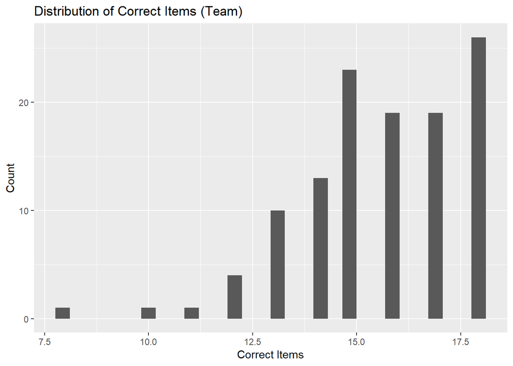

```r
#dependent_response_team <- "CI_team"
y_label_team <- "Count"
x_label_team <- params$dependent_response_name_WithSpace
title_response_team <- paste("Distribution of", params$dependent_response_name_WithSpace, "(Team)")
plot_name <- paste("Histogram_", params$dependent_response_name_NoSpace, "_Team.png", sep = "")
setwd(figure_directory)

plot_data_team <- team_data %>%
  select(params$dependent_response_team, Target)

ggplot(data = plot_data_team) +
  geom_histogram(aes_string(x = params$dependent_response_team), bins = 30) +
  labs(title = title_response_team, x = x_label_team, y = y_label_team) +
  ggsave(filename = plot_name)
```

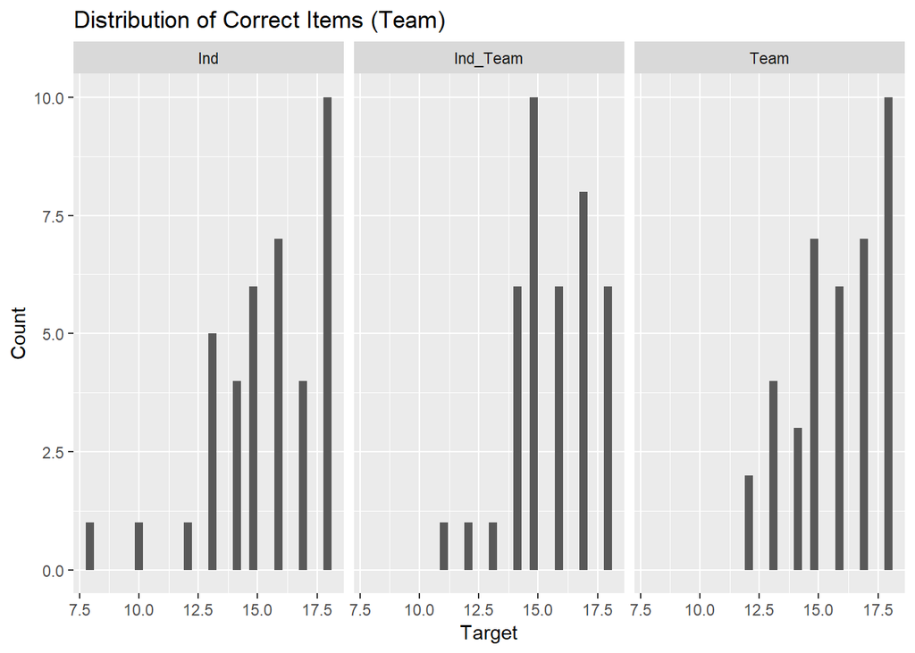

```r
#dependent_response_team <- "CI_team"
y_label_team <- "Count"
x_label_team <- "Target"
title_response_team <- paste("Distribution of", params$dependent_response_name_WithSpace, "(Team)")
plot_name <- paste("Histogram_", params$dependent_response_name_NoSpace, "_ByTarget_Team.png", sep=)
setwd(figure_directory)

plot_data_team <- team_data %>%
  select(params$dependent_response_team, Target)

ggplot(data = plot_data_team) +
  geom_histogram(aes_string(x = params$dependent_response_team), bins = 30) +
  facet_grid(. ~ Target) +
  labs(title = title_response_team, x = x_label_team, y = y_label_team) +
  ggsave(filename = plot_name)
```

```r
# Information about the N values in each condition
tableData <- team_data %>%
  group_by(Target) %>%
  summarise(N = length(.data[[params$dependent_response_team]]))

tableData %>%
  kable() %>%
  kable_styling()
```

| Target | N |
| --- | --- |
| Ind | 39 |
| Ind_Team | 39 |
| Team | 39 |

Overall, it looks like the data shows a similar distribution when grouped by Target. The data skews to the right. It is interesting to note that the team condition has a slightly larger skew to the right.

**Reflection:** Overall, the main distribution of the data is similar to the distribution of the data when broken to the different target groups. The interesting note is that the Team condition seems to have a greater skew to the right. This indicates that groups in the Team condition were able to collect more of the correct team items.

#### Individual

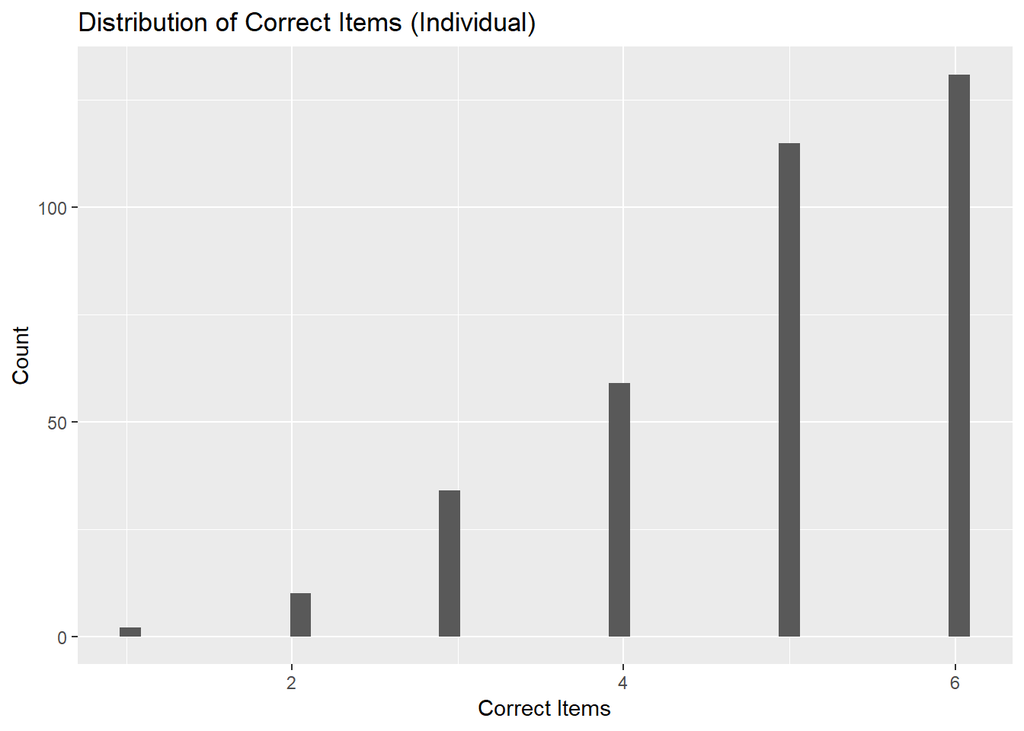

```r
#dependent_response_ind <- "CI_ind"
y_label_ind <- "Count"
x_label_ind <- params$dependent_response_name_WithSpace
title_response_ind <- paste("Distribution of", params$dependent_response_name_WithSpace, "(Individual)")
plot_name <- paste("Histogram_", params$dependent_response_name_NoSpace, "_Ind.png", sep="")
setwd(figure_directory)

plot_data_ind <- ind_data %>%
  select(params$dependent_response_ind, Target)

ggplot(data = plot_data_ind) +
  geom_histogram(aes_string(x = params$dependent_response_ind), bins = 40) +
  labs(title = title_response_ind, x = x_label_ind, y = y_label_ind) +
  ggsave(filename = plot_name)
```

Overall, the data is skewed to the right. Specifically, most participants were able to collect at least 3 or 4 items.

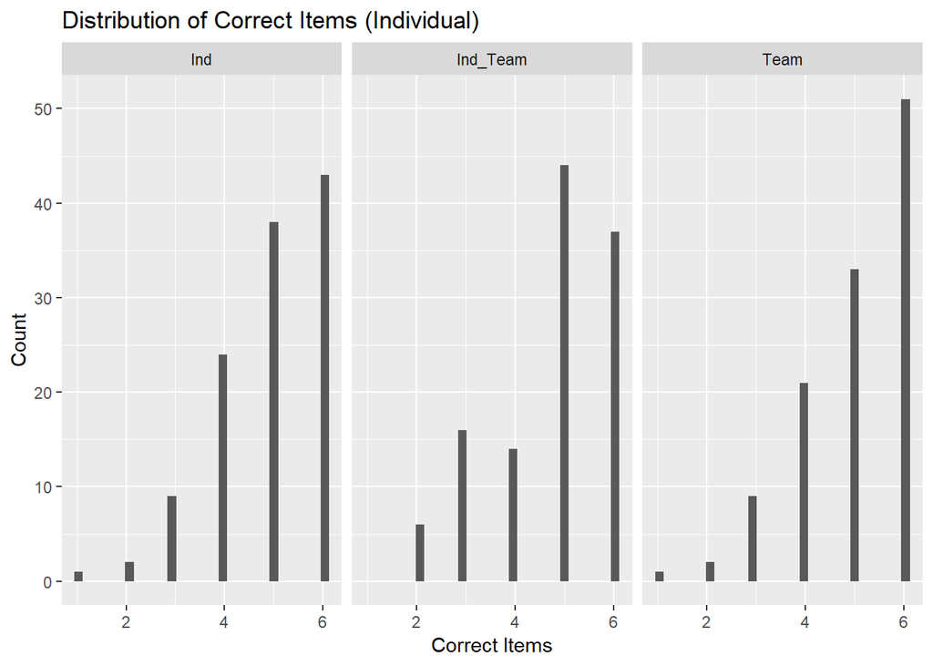

```r
#dependent_response_ind <- "CI_ind"
y_label_ind <- "Count"
x_label_ind <- params$dependent_response_name_WithSpace
title_response_ind <- paste("Distribution of", params$dependent_response_name_WithSpace, "(Individual)")
plot_name <- paste("Histogram_", params$dependent_response_name_NoSpace, "_ByTarget_Ind.png", sep="")
setwd(figure_directory)

plot_data_ind <- ind_data %>%
  select(params$dependent_response_ind, Target)

ggplot(data = plot_data_ind) +
  geom_histogram(aes_string(x = params$dependent_response_ind), bins = 30) +
  facet_grid(. ~ Target) +
  labs(title = title_response_ind, x = x_label_ind, y = y_label_ind) +
  ggsave(filename = plot_name)
```

```r
# Information about the N values in each condition
tableData <- ind_data %>%
  group_by(Target) %>%
  summarise(N = length(.data[[params$dependent_response_ind]]))

tableData %>%
  kable() %>%
  kable_styling()
```

| Target | N |
| --- | --- |
| Ind | 117 |
| Ind_Team | 117 |
| Team | 117 |

Overall, it seems as though the distrabution of the data grouped by the target level is similar to the overall distrabution. It is interesting to note that the Ind and Team condition seem to have similar distrabutions. Specifically, most participants were able to collected at least 3 or 4 individual items. In the Ind_Team condition, it seems as though about 30 or 40 participants were were only abel to collect 2 to 4 individual items, while the rest were able to collect about 5 or 6 items.

**Reflection:** Overall, it looks like the data distrabution when grouped by Target is similar to the overall distrabution of the data. An interesting note is that the distrabution of the data in the Team and Ind condition are similar. In the Ind_Team condition it seems as though participants were able to collect either 2-4 items or 5 - 6 items.

#### Summary / Reflection

Overall, there was skewness in the data at the individual and team level.

At the team level, there seems to be a slightly bigger skew to the right in the Team condition when compared to the Ind_Team and Ind condition. This could be an indiciation that groups in the Team condition were able to collect more team items than in the other conditions.

At the individual level, it seems as though the Ind and Team condition had similar distrabutions, while the Ind_Team condition seemed to have less skewness than when compared to the Ind and Team condition. This could be an indication that the individuals were able to collect more correct individual items in the Team or Ind condition, but not as much in the Ind_Team condition.

No obvious pattern jumps out at me. However, its seems as though there may be something interesting happening in the Team condition. What does the distrabution look like if we include session order?

### Q: Is there exciting variation among the Correct Items that explains how the feedback conditions influence the Correct Items when session order is taken into consideration?

#### Team

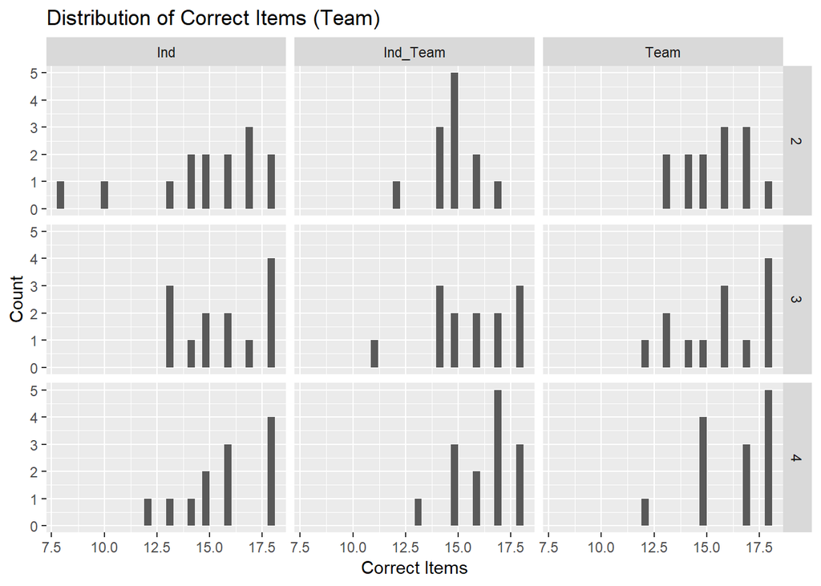

```r
#dependent_response_team <- "CI_team"
y_label_team <- "Count"
x_label_team <- params$dependent_response_name_WithSpace
title_response_team <- paste("Distribution of", params$dependent_response_name_WithSpace, "(Team)")
plot_name <- paste("Histogram_", params$dependent_response_name_NoSpace, "_ByTarget_BySessionOrder_Team.png", sep="")
setwd(figure_directory)

plot_data_team <- team_data %>%
  select(params$dependent_response_team, Target, SessionOrder)

ggplot(data = plot_data_team) +
  geom_histogram(aes_string(x = params$dependent_response_team), bins = 30) +
  labs(title = title_response_team, x = x_label_team, y = y_label_team) +
  facet_grid( SessionOrder ~ Target) +
  ggsave(filename = plot_name)
```

```r
# Information about the N values in each condition
tableData <- team_data %>%
  select(params$dependent_response_team, Target, SessionOrder) %>%
  group_by(Target, SessionOrder) %>%
  summarise(N = length(.data[[params$dependent_response_team]]))

tableData %>%
  kable() %>%
  kable_styling()
```

| Target | SessionOrder | N |
| --- | --- | --- |
| Ind | 2 | 14 |
| Ind | 3 | 13 |
| Ind | 4 | 12 |
| Ind_Team | 2 | 12 |
| Ind_Team | 3 | 13 |
| Ind_Team | 4 | 14 |
| Team | 2 | 13 |
| Team | 3 | 13 |
| Team | 4 | 13 |

Overall, it looks like the data moves to the right over time. In other words, the participants were able to collect more and more items. Something that may be worth noting is that the distribution of the data in the Ind condition seems to stay constant, as opposed to moving to the right.

*Refelction:* The data seems to have a similar distribution as the main overall data distribution. An interesting note is that the Ind condition appears to have the same distribution from session to session. This could indicate that the intervention had no effect on how many items the teams collected or that it reduced the number of items collected by the teams and that negated any performance gained by experience.

#### Individual

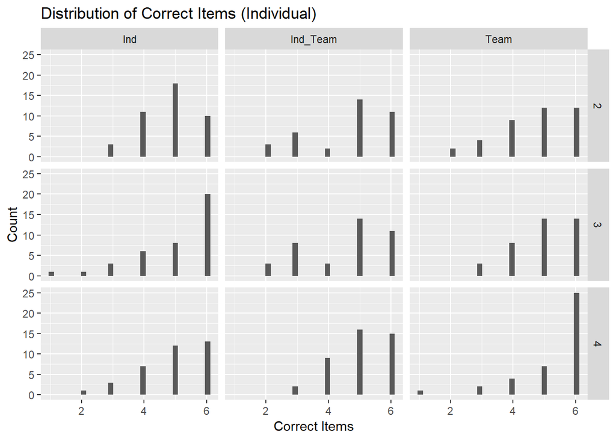

```r
#dependent_response_ind <- "CI_ind"
y_label_ind <- "Count"
x_label_ind <- params$dependent_response_name_WithSpace
title_response_ind <- paste("Distribution of", params$dependent_response_name_WithSpace, "(Individual)")
plot_name <- paste("Histogram_", params$dependent_response_name_NoSpace, "_ByTarget_BySessionOrder_Ind.png", sep="")
setwd(figure_directory)

plot_data_ind <- ind_data %>%
  select(params$dependent_response_ind, Target, SessionOrder)

ggplot(data = plot_data_ind) +
  geom_histogram(aes_string(x = params$dependent_response_ind), bins = 30) +
  facet_grid(SessionOrder ~ Target) +
  labs(title = title_response_ind, x = x_label_ind, y = y_label_ind) +
  ggsave(filename = plot_name)
```

```r
# Information about the N values in each condition
tableData <- ind_data %>%
  select(params$dependent_response_ind, Target, SessionOrder) %>%
  group_by(Target, SessionOrder) %>%
  summarise(N = length(.data[[params$dependent_response_ind]]))

tableData %>%
  kable() %>%
  kable_styling()
```

| Target | SessionOrder | N |
| --- | --- | --- |
| Ind | 2 | 42 |
| Ind | 3 | 39 |
| Ind | 4 | 36 |
| Ind_Team | 2 | 36 |
| Ind_Team | 3 | 39 |
| Ind_Team | 4 | 42 |
| Team | 2 | 39 |
| Team | 3 | 39 |
| Team | 4 | 39 |

Overall, it looks like the data distribution skews to the right over time.

In the Ind condition, there seems to be little change in the distribution of the data.

In the Ind_Team condition, session 2 and 3 seem to have similar distributions. Session 4 distribution appears to move more to the right.

In the Team condition, distribution in session 2 and 3 are similar, but session 4 has more of skew to the right.

In session 4, it seems as though the Ind condition and Ind_Team condition have a similar distribution and the distribution in the Team condition.

**Reflection:** Overall, there appears to be no obvious pattern. It is worth noting that the distribution in the Ind conditions seems to go unchanged from session to session. This could mean that the intervention had no effect or had a negative impact on participants collecting correct individuals items. In the Ind_Team and Team condition, it looks like a major improvement (i.e., a more obvious skew to the right) happens when moving from session 3 to session 4. This indicates that something happens between sessions 3 and 4 to increase performance. It seems as though the skew in the Team condition in session 4 is greater than the skew in the Ind and Ind_Team conditions.

#### Summary / Reflection

Overall, there were no obvious patterns.

At the individual and team level, the Ind condition seemed to have either no influence or a negative influence on the correct items collected. Also, the Team condition seemed to have the biggest skew (i.e., most data seemed to be to the right) at both levels. This would indicate that the Team condition had a positive influence on the correct items collected over time.

### Q: Is there an *interaction* between the Target and Session Order for the **Correct Items**?

I am interested in this question for modeling purposes. I want to know if I need to include the interaction between Target and Session Order.

#### Team

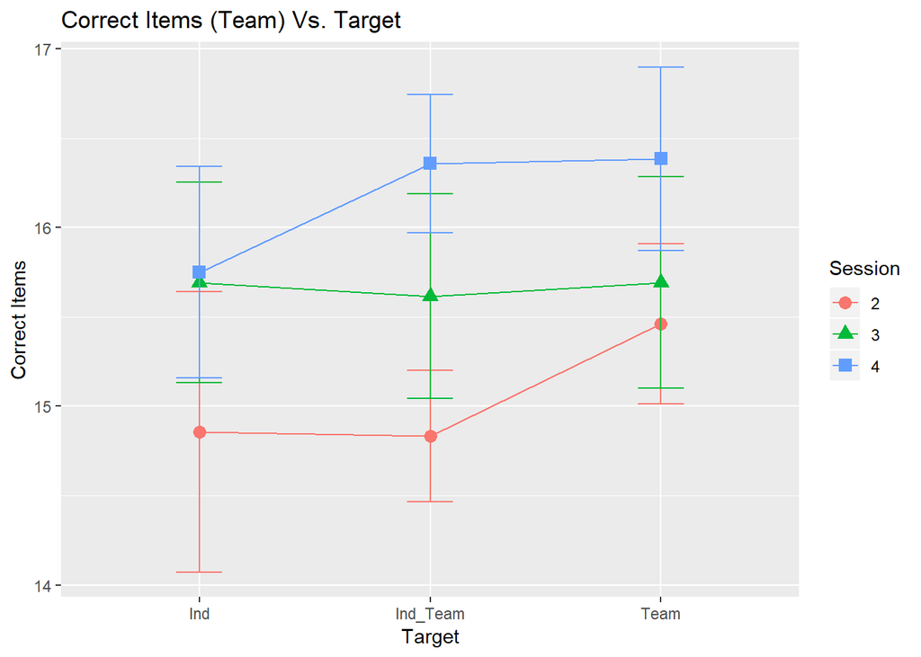

```r
#dependent_response_team <- "CI_team"
y_label_team <- params$dependent_response_name_WithSpace
x_label_team <- "Target"
title_response_team <- paste(params$dependent_response_name_WithSpace, "(Team) Vs. Target")
plot_name <- paste("InteractionPlot_", params$dependent_response_name_NoSpace, "_ByTarget_BySessionOrder_Team.png", sep="")
setwd(figure_directory)

plot_data_team <- team_data %>%
  select(Target, SessionOrder, params$dependent_response_team) %>%
  group_by(SessionOrder, Target) %>%
  summarise(dependentAverage = mean(.data[[params$dependent_response_team]]),
            Stdv =sd(.data[[params$dependent_response_team]]), n = length(.data[[params$dependent_response_team]]),
            StEr = sd(.data[[params$dependent_response_team]]) / sqrt(length(.data[[params$dependent_response_team]])))

ggplot(data = plot_data_team, aes(x = Target, y = dependentAverage, color = SessionOrder, shape = SessionOrder)) +
  geom_point(size = 3) +
  geom_line(aes(group=SessionOrder, color = SessionOrder)) +
  geom_errorbar(aes(ymin = dependentAverage - StEr, ymax = dependentAverage + StEr), width = 0.2) +
  labs(y = y_label_team, x = x_label_team, title = title_response_team, color = "Session", shape = "Session") +
  ggsave(filename = plot_name)
```

```r
plot_data_team %>%
  kable() %>%
  kable_styling()
```

| SessionOrder | Target | dependentAverage | Stdv | n | StEr |
| --- | --- | --- | --- | --- | --- |
| 2 | Ind | 14.85714 | 2.931451 | 14 | 0.7834633 |
| 2 | Ind_Team | 14.83333 | 1.267305 | 12 | 0.3658393 |
| 2 | Team | 15.46154 | 1.613246 | 13 | 0.4474341 |
| 3 | Ind | 15.69231 | 2.015962 | 13 | 0.5591272 |
| 3 | Ind_Team | 15.61538 | 2.063107 | 13 | 0.5722029 |
| 3 | Team | 15.69231 | 2.136376 | 13 | 0.5925241 |
| 4 | Ind | 15.75000 | 2.050499 | 12 | 0.5919280 |
| 4 | Ind_Team | 16.35714 | 1.446861 | 14 | 0.3866899 |
| 4 | Team | 16.38462 | 1.850156 | 13 | 0.5131409 |

Also, it appears that the highest average for session 2 occurs in the Team condition. This suggests that teams collected more correct items in session 2 when put in the Team condition.

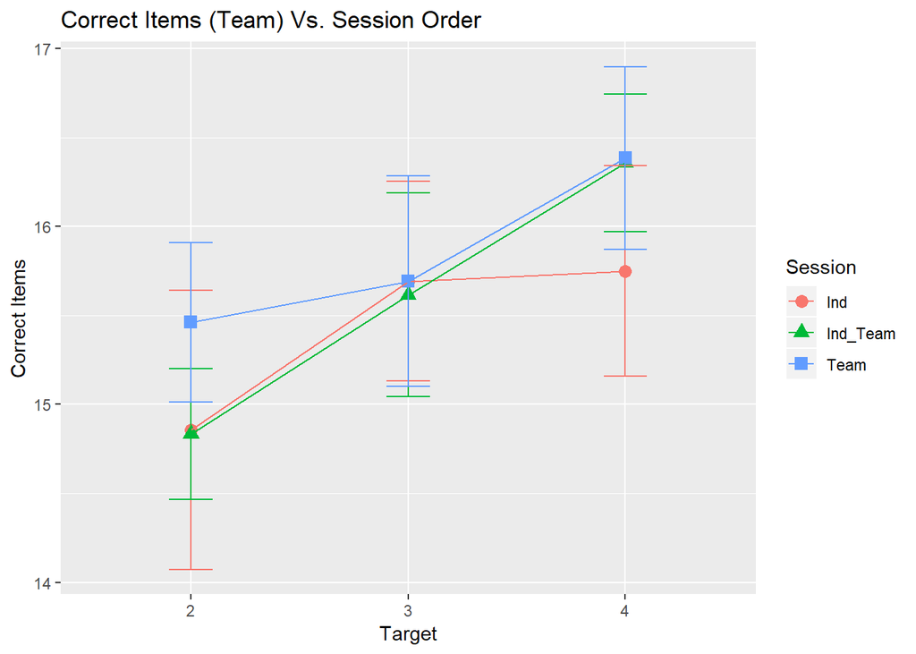

```r
#dependent_response_team <- "CI_team"
y_label_team <- params$dependent_response_name_WithSpace
x_label_team <- "Target"
title_response_team <- paste(params$dependent_response_name_WithSpace,"(Team) Vs. Session Order")
plot_name <- paste("InteractionPlot_", params$dependent_response_name_NoSpace, "_BySessionOrder_ByTarget_Team.png", sep="")
setwd(figure_directory)

plot_data_team <- team_data %>%
  select(Target, SessionOrder, params$dependent_response_team) %>%
  group_by(SessionOrder, Target) %>%
  summarise(DependentAverage = mean(.data[[params$dependent_response_team]]),
            Stdv =sd(.data[[params$dependent_response_team]]), n = length(.data[[params$dependent_response_team]]),
            StEr = sd(.data[[params$dependent_response_team]]) / sqrt(length(.data[[params$dependent_response_team]])))

ggplot(data = plot_data_team, aes(x = SessionOrder , y = DependentAverage, color = Target, shape = Target)) +
  geom_point(size = 3) +
  geom_line(aes(group=Target, color = Target)) +
  geom_errorbar(aes(ymin = DependentAverage - StEr, ymax = DependentAverage + StEr), width = 0.2) +
  labs(y = y_label_team, x = x_label_team, title = title_response_team, color = "Session", shape = "Session") +
  ggsave(filename = plot_name)
```

Overall, there seems to be an interaction between Session Order and Target.

The Ind condition seems to improve from session 2 to 3 but stays the same from session 3 to 4.

The Ind_Team condition steadily improves over time.

The Team condition improves a little from session 2 to 3 but has a bigger improvement from session 3 to 4.

#### Individual

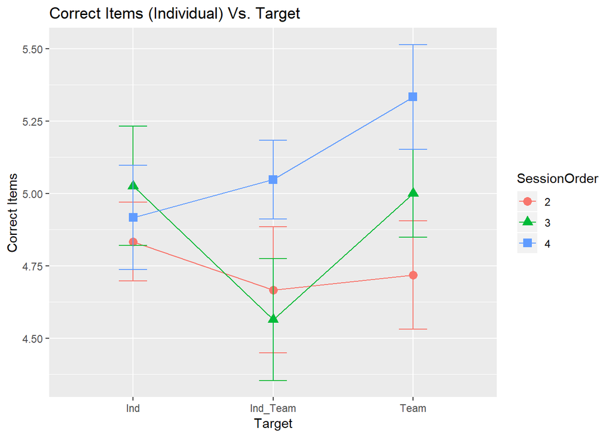

```r
#dependent_response_ind <- "CI_ind"
y_label_ind <- params$dependent_response_name_WithSpace
x_label_ind <- "Target"
title_response_ind <- paste(params$dependent_response_name_WithSpace, "(Individual) Vs. Target")
plot_name <- paste("InteractionPlot_", params$dependent_response_name_NoSpace, "_ByTarget_BySessionOrder_Ind.png", sep="")
setwd(figure_directory)

plot_data_ind <- ind_data %>%
  select(Target, SessionOrder, params$dependent_response_ind) %>%
  group_by(SessionOrder, Target) %>%
  summarise(Average = mean(.data[[params$dependent_response_ind]]),
            Stdv =sd(.data[[params$dependent_response_ind]]),
            n = length(.data[[params$dependent_response_ind]]),
            StEr = sd(.data[[params$dependent_response_ind]]) / sqrt(length(.data[[params$dependent_response_ind]])))

ggplot(data = plot_data_ind, aes(x = Target, y = Average, color = SessionOrder, shape=SessionOrder)) +
  geom_point(size = 3) +
  geom_line(aes(group=SessionOrder, color = SessionOrder)) +
  geom_errorbar(aes(ymin = Average - StEr, ymax = Average + StEr), width = 0.2) +
  labs(y = y_label_ind, x = x_label_ind, title = title_response_ind, fill = "Players") +
  ggsave(filename = plot_name)
```

```r
plot_data_ind %>%
  kable() %>%
  kable_styling()
```

| SessionOrder | Target | Average | Stdv | n | StEr |
| --- | --- | --- | --- | --- | --- |
| 2 | Ind | 4.833333 | 0.8811485 | 42 | 0.1359642 |
| 2 | Ind_Team | 4.666667 | 1.3093073 | 36 | 0.2182179 |
| 2 | Team | 4.717949 | 1.1686411 | 39 | 0.1871323 |
| 3 | Ind | 5.025641 | 1.2873306 | 39 | 0.2061379 |
| 3 | Ind_Team | 4.564103 | 1.3137907 | 39 | 0.2103749 |
| 3 | Team | 5.000000 | 0.9459053 | 39 | 0.1514661 |
| 4 | Ind | 4.916667 | 1.0790207 | 36 | 0.1798368 |
| 4 | Ind_Team | 5.047619 | 0.8821366 | 42 | 0.1361166 |
| 4 | Team | 5.333333 | 1.1316809 | 39 | 0.1812140 |

Overall, there appears to be an interaction occurring between the Session Order and Target variable. In the Team condition, the number of correct items collected seems to improve over time. In the Ind_Team condition going from session 2 to session 3, the number of correct items decreases. In the Ind condition going from session 3 to 4, the number of correct items collected drops.

**Reflection:** There does seem to be interaction occurring in this plot, but it does not appear to be a strong interaction.

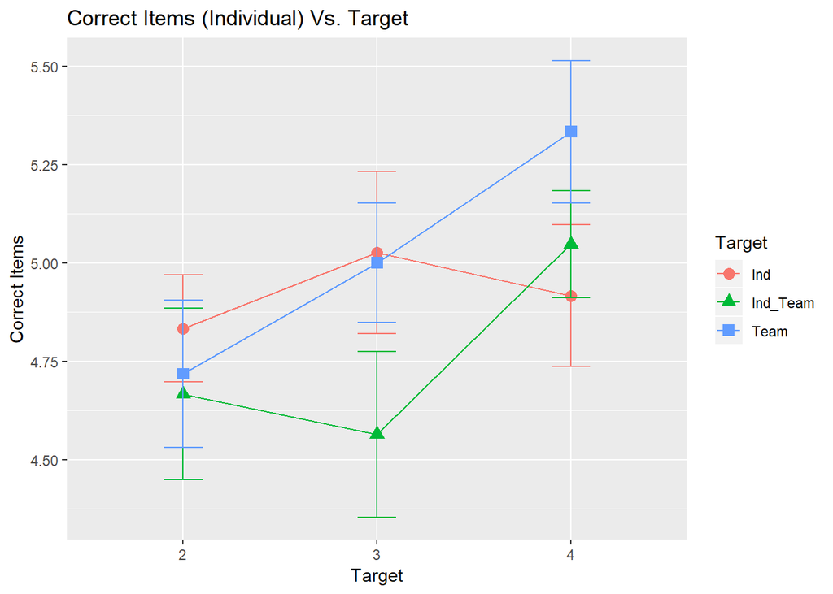

```r
#dependent_response_ind <- "CI_ind"
y_label_ind <- params$dependent_response_name_WithSpace
x_label_ind <- "Target"
title_response_ind <- paste(params$dependent_response_name_WithSpace, "(Individual) Vs. Target")
plot_name <- paste("InteractionPlot_", params$dependent_response_name_NoSpace, "_BySessionOrder_ByTarget_Ind.png", sep = "")
setwd(figure_directory)

plot_data_ind <- ind_data %>%
  select(Target, SessionOrder, params$dependent_response_ind) %>%
  group_by(SessionOrder, Target) %>%
  summarise(Average = mean(.data[[params$dependent_response_ind]]),
            Stdv =sd(.data[[params$dependent_response_ind]]),
            n = length(.data[[params$dependent_response_ind]]),
            StEr = sd(.data[[params$dependent_response_ind]]) / sqrt(length(.data[[params$dependent_response_ind]])))

ggplot(data = plot_data_ind, aes(x = SessionOrder, y = Average, color = Target, shape=Target)) +
  geom_point(size = 3) +
  geom_line(aes(group=Target, color = Target)) +
  geom_errorbar(aes(ymin = Average - StEr, ymax = Average + StEr), width = 0.2) +
  labs(y = y_label_ind, x = x_label_ind, title = title_response_ind, fill = "Players") +
  ggsave(filename = plot_name)
```

Overall, there seems to be some interaction with the data.

In session 2, there seems to be little difference between the conditions.

In session 3, the Ind_Team condition is the lowest. The Team and Ind condition are similar.

In session 4, the Team condition has the highest average correct items collected.

**Reflection:** There seems to be an interaction between the Target and the Session Order. There also seems to be a slight drop in correct items collected (i.e., performance) for the Ind_Team and Ind condition. The Team condition is the only condition that seems to steadly increas over time. This suggests that the Team condtion prodcued the most realiable amount of correct items collected at the individual level.

#### Summary /Reflection

Overall, there some seems to be some interaction occuring within the data. It seems as though the team condition produces the highest value of correct items collected. The team condtion also appears to realiably increase over time, while other conditions seem to decrease a little between sessions. The next step is to determine if any of these interactions are statistically significant.

### Q: Is there an interaction between the Target and Session Order for the **Correct Items** that is statistically significant?

I am interested in determining if a linear mixed effect model should include the interaction effect between the Target and Session Order variable.

A note on the effect size ($R^2$). This method generates two types of ($R^2$) values called marginal ($R_{m}^2$) and conditional ($R_{c}^2$) effect size. The $R_{m}^2$ calculates how much of the variance is described by the fixed effect variables (feedback condition and session order) while the $R_{c}^2$ calculates how much of the variance is described by both the fixed and random effect variables.

#### Full Models Used for Team and Individual

The next two sections below describe the full model for team and individual level analysis. Five models were fitted and then compared. One model was the null model, one model was the full model, and the last three are a subset of the full model.

##### Team Full Model

$$y_{ijt} = \mu + \alpha_{i} + \beta_{j} + \alpha_{i} \beta_{j} + \gamma_{t} + \epsilon_{ijt}$$

##### Individual Team Full Model

$$y_{ijtp} = \mu + \alpha_{i} + \beta_{j} + \alpha_{i} \beta_{j} + \gamma_{t} + \theta_{p} + \epsilon_{ijtp}$$

##### Team

```r
# Response variable
#response_variable <- "CI_team"

# Data to fit
data_modified_team <- team_data %>%
  select(TeamScore,
         params$dependent_response_team,
         Target,
         SessionOrder,
         Team)

# Generate models with variable response
data_focus_team <- data_modified_team
model.null <- model_data_Target_Session(df = data_focus_team, dependent =  params$dependent_response_team, model.type =  "null", is.team = TRUE, is.robust =FALSE)
model.All <- model_data_Target_Session(df = data_focus_team, dependent =  params$dependent_response_team, model.type =  "All", is.team = TRUE, is.robust = FALSE)
model.NoInteraction <- model_data_Target_Session(df = data_focus_team, dependent =  params$dependent_response_team, model.type =  "NoInteraction", is.team = TRUE, is.robust = FALSE)
model.NoInteraction.NoTarget <- model_data_Target_Session(df = data_focus_team, dependent =  params$dependent_response_team, model.type =  "NoInteraction_NoTarget", is.team = TRUE, is.robust = FALSE)
model.NoInteraction.NoSession <- model_data_Target_Session(df = data_focus_team, dependent =  params$dependent_response_team, model.type =  "NoInteraction_NoSession", is.team = TRUE, is.robust = FALSE)

# There is an option to compare all the models with the anova(). However, the function does not compare all models to model.null
anova(model.null,
      model.All) %>%
  kable(caption = "ANOVA: Null and All") %>%
  kable_styling()
```

ANOVA: Null and All

|  | Df | AIC | BIC | logLik | deviance | Chisq | Chi Df | Pr(>Chisq) |
| --- | --- | --- | --- | --- | --- | --- | --- | --- |
| model.null | 3 | 490.9676 | 499.2541 | -242.4838 | 484.9676 | NA | NA | NA |
| model.All | 11 | 495.1073 | 525.4912 | -236.5536 | 473.1073 | 11.86029 | 8 | 0.1575471 |

```r
anova(model.null,
      model.NoInteraction) %>%
  kable(caption = "ANOVA: Null and No.Interaction") %>%
  kable_styling()
```

ANOVA: Null and No.Interaction

|  | Df | AIC | BIC | logLik | deviance | Chisq | Chi Df | Pr(>Chisq) |
| --- | --- | --- | --- | --- | --- | --- | --- | --- |
| model.null | 3 | 490.9676 | 499.2541 | -242.4838 | 484.9676 | NA | NA | NA |
| model.NoInteraction | 7 | 488.5609 | 507.8961 | -237.2805 | 474.5609 | 10.40664 | 4 | 0.0341076 |

```r
anova(model.null,
      model.NoInteraction.NoTarget) %>%
  kable(caption = "ANOVA: Null and No.Interaction.No.Target") %>%
  kable_styling()
```

ANOVA: Null and No.Interaction.No.Target

|  | Df | AIC | BIC | logLik | deviance | Chisq | Chi Df | Pr(>Chisq) |
| --- | --- | --- | --- | --- | --- | --- | --- | --- |
| model.null | 3 | 490.9676 | 499.2541 | -242.4838 | 484.9676 | NA | NA | NA |
| model.NoInteraction.NoTarget | 5 | 485.8382 | 499.6490 | -237.9191 | 475.8382 | 9.129406 | 2 | 0.010413 |

```r
anova(model.null,
      model.NoInteraction.NoSession) %>%
  kable(caption = "ANOVA: Null and No.Interaction.No.Session") %>%
  kable_styling()
```

ANOVA: Null and No.Interaction.No.Session

|  | Df | AIC | BIC | logLik | deviance | Chisq | Chi Df | Pr(>Chisq) |
| --- | --- | --- | --- | --- | --- | --- | --- | --- |
| model.null | 3 | 490.9676 | 499.2541 | -242.4838 | 484.9676 | NA | NA | NA |
| model.NoInteraction.NoSession | 5 | 493.6729 | 507.4837 | -241.8364 | 483.6729 | 1.29471 | 2 | 0.5234285 |

The folowing models are significantly different from the null model: model.NoInteraction, model. NoInteraction.NoTarget.

model.NoInteraction: Session order and target are the fixed effects in this model.

model.NoInteraction.NoTarget: Session order is the only fixed effect in this model.

I noticed that both models do not include the Interaction betweent the terms.

I want to compare the models that are significanntly different from the null model (i.e., the models mentioned above) and compare them with one another. The goal is to see if the extra terms improve the model.

```r
# Response variable
#response_variable <- "CI_team"

# Data to fit
data_modified_team <- team_data %>%
  select(TeamScore,
         params$dependent_response_team,
         Target,
         SessionOrder,
         Team)

# Generate models with variable response
data_focus_team <- data_modified_team

model.NoInteraction <- model_data_Target_Session(df = data_focus_team, dependent =  params$dependent_response_team, model.type =  "NoInteraction", is.team = TRUE, is.robust = FALSE)
model.NoInteraction.NoTarget <- model_data_Target_Session(df = data_focus_team, dependent =  params$dependent_response_team, model.type =  "NoInteraction_NoTarget", is.team = TRUE, is.robust = FALSE)

# Compare all of the models
anova(model.NoInteraction,
      model.NoInteraction.NoTarget) %>%
  kable(caption = "ANOVA: model.NoInteraction and model.NoInteraction.NoTarget") %>%
  kable_styling()
```

```
## refitting model(s) with ML (instead of REML)
```

ANOVA: model.NoInteraction and model.NoInteraction.NoTarget

|  | Df | AIC | BIC | logLik | deviance | Chisq | Chi Df | Pr(>Chisq) |
| --- | --- | --- | --- | --- | --- | --- | --- | --- |
| model.NoInteraction.NoTarget | 5 | 485.8382 | 499.6490 | -237.9191 | 475.8382 | NA | NA | NA |
| model.NoInteraction | 7 | 488.5609 | 507.8961 | -237.2805 | 474.5609 | 1.277231 | 2 | 0.5280229 |

The results show that the model.NoInteraction model was not significantly better at describing the data than the model.NoIteraction.NoTarget. In other words, the results show that the model.NoInteraction is not significantly different from model.NoInteraction.NoTarget. This lack of significance suggests that the model.NoInteraction.NoTarget describes the data best. I noticed there is a small difference in the AIC (2.7227686) and the BIC (8.2471165) criteria values. Due to the small AIC and BIC difference between the two models, I cannot confidently say one model is clearly better than the other model, though the model.NoInteraction.NoTarget is a slightly better model.

I want to calculate the effect size of both models to see if there is a noticeable difference between the effect sizes.

```r
# Response variable
#response_variable <- "CI_team"

# Data to fit
data_modified_team <- team_data %>%
  select(TeamScore,
         params$dependent_response_team,
         Target,
         SessionOrder,
         Team)

# Generate models with variable response
data_focus_team <- data_modified_team

model.NoInteraction <- model_data_Target_Session(df = data_focus_team, dependent =  params$dependent_response_team, model.type =  "NoInteraction", is.team = TRUE, is.robust = FALSE)
model.NoInteraction.NoTarget <- model_data_Target_Session(df = data_focus_team, dependent =  params$dependent_response_team, model.type =  "NoInteraction_NoTarget", is.team = TRUE, is.robust = FALSE)

# Effect size (R^2)

r.squaredGLMM(model.NoInteraction.NoTarget) %>%
  kable(caption = "Table: Effect size for *No Interaction and No Target*") %>%
   kable_styling(full_width = F)
```

Table: Effect size for *No Interaction and No Target*

| R2m | R2c |
| --- | --- |
| 0.0530848 | 0.3474655 |

```r
r.squaredGLMM(model.NoInteraction) %>%
  kable(caption = "Table: Effect size for *No Interaction*") %>%
   kable_styling(full_width = F)
```

Table: Effect size for *No Interaction*

| R2m | R2c |
| --- | --- |
| 0.0593492 | 0.3481739 |

There is little difference between the effect sizes for both models. The results show that model.NoInteraction has a slightly better effect size, but the difference is not noticeably different.

**Reflection:** Overall, the data suggests no strong interaction between Target and Session Order variables. Two models were significantly different from the model.null: **model.NoInteraction** and **model.NoInteraction.NoTarget**. In the **model.NoInteraction**, the Target and Session Order variable are present. In the **model.NoInteraction.NoTarget**, only the Session Order variable is present. This suggests that the session order variable is the best predictor of the data. However, after more examination of both models (i.e., **model.NoInteraction.NoTarget** and **model.NoInteraction**), I was not confident in ignoring the **model.NoInteraction** for two reasons. First, there was a small difference between the AIC and BIC values. The “better” model has a lower BIC or AIC value. The **model.NoInteraction.NoTarget** had a slightly better BIC and AIC value, meaning that the model is “better” than the **model.NoInteraction.NoTarget**. Second, the effect sizes for both models were very similar. The similar effect sizes indicate that the models have a similar capability in describing the data.

##### Individual

```r
# Response Variable

#response_variable <- "CI_ind"

# Data to model
data_modified_ind <- ind_data %>%
  select(params$dependent_response_ind,
         Target,
         SessionOrder,
         Team,
         Player_ID)

data_focus_ind <- data_modified_ind
model.null <- model_data_Target_Session(df = data_focus_ind, dependent =  params$dependent_response_ind, model.type =  "null", is.team = FALSE, is.robust = FALSE)
model.All <- model_data_Target_Session(df = data_focus_ind, dependent =  params$dependent_response_ind, model.type =  "All", is.team = FALSE, is.robust = FALSE)
model.NoInteraction <- model_data_Target_Session(df = data_focus_ind, dependent =  params$dependent_response_ind, model.type =  "NoInteraction", is.team = FALSE, is.robust = FALSE)
model.NoInteraction.NoTarget <- model_data_Target_Session(df = data_focus_ind, dependent =  params$dependent_response_ind, model.type =  "NoInteraction_NoTarget", is.team = FALSE, is.robust = FALSE)
model.NoInteraction.NoSession <- model_data_Target_Session(df = data_focus_ind, dependent =  params$dependent_response_ind, model.type =  "NoInteraction_NoSession", is.team = FALSE, is.robust = FALSE)

# There is an option to compare all the models with the anova(). However, the function does not compare all models to model.null
anova(model.null,
      model.All) %>%
  kable(caption = "ANOVA: model.null and model.All") %>%
  kable_styling()
```

```
## refitting model(s) with ML (instead of REML)
```

ANOVA: model.null and model.All

|  | Df | AIC | BIC | logLik | deviance | Chisq | Chi Df | Pr(>Chisq) |
| --- | --- | --- | --- | --- | --- | --- | --- | --- |
| model.null | 4 | 1042.043 | 1057.486 | -517.0216 | 1034.043 | NA | NA | NA |
| model.All | 12 | 1039.162 | 1085.491 | -507.5809 | 1015.162 | 18.8813 | 8 | 0.0155075 |

```r
anova(model.null,
      model.NoInteraction) %>%
  kable(caption = "ANOVA: model.null and model.NoInteraction") %>%
  kable_styling()
```

```
## refitting model(s) with ML (instead of REML)
```

ANOVA: model.null and model.NoInteraction

|  | Df | AIC | BIC | logLik | deviance | Chisq | Chi Df | Pr(>Chisq) |
| --- | --- | --- | --- | --- | --- | --- | --- | --- |
| model.null | 4 | 1042.043 | 1057.486 | -517.0216 | 1034.043 | NA | NA | NA |
| model.NoInteraction | 8 | 1035.415 | 1066.301 | -509.7074 | 1019.415 | 14.62831 | 4 | 0.0055376 |

```r
anova(model.null,
      model.NoInteraction.NoTarget) %>%
  kable(caption = "ANOVA: model.null and model.NoInteraction.NoTarget") %>%
  kable_styling()
```

```
## refitting model(s) with ML (instead of REML)
```

ANOVA: model.null and model.NoInteraction.NoTarget

|  | Df | AIC | BIC | logLik | deviance | Chisq | Chi Df | Pr(>Chisq) |
| --- | --- | --- | --- | --- | --- | --- | --- | --- |
| model.null | 4 | 1042.043 | 1057.486 | -517.0216 | 1034.043 | NA | NA | NA |
| model.NoInteraction.NoTarget | 6 | 1036.485 | 1059.650 | -512.2427 | 1024.485 | 9.557751 | 2 | 0.0084054 |

```r
anova(model.null,
      model.NoInteraction.NoSession) %>%
  kable(caption = "ANOVA: model.null and model.NoInteraction.NoSession") %>%
  kable_styling()
```

```
## refitting model(s) with ML (instead of REML)
```

ANOVA: model.null and model.NoInteraction.NoSession

|  | Df | AIC | BIC | logLik | deviance | Chisq | Chi Df | Pr(>Chisq) |
| --- | --- | --- | --- | --- | --- | --- | --- | --- |
| model.null | 4 | 1042.043 | 1057.486 | -517.0216 | 1034.043 | NA | NA | NA |
| model.NoInteraction.NoSession | 6 | 1041.612 | 1064.777 | -514.8062 | 1029.612 | 4.430763 | 2 | 0.1091119 |

The following models were significantly better than the null model: model.All, model.NoInteraction, and model.NoInteraction.NoTarget.

model.All: Session Order, Target, and the interaction are included in this model.

model.NoInteraction: Session order and target are the fixed effects in this model.

model.NoInteraction.NoTarget: Session order is the only fixed effect in this model.

```r
# Response Variable

#response_variable <- "CI_ind"

# Data to model
data_modified_ind <- ind_data %>%
  select(params$dependent_response_ind,
         Target,
         SessionOrder,
         Team,
         Player_ID)

data_focus_ind <- data_modified_ind
model.All <- model_data_Target_Session(df = data_focus_ind, dependent =  params$dependent_response_ind, model.type =  "All", is.team = FALSE, is.robust = FALSE)
model.NoInteraction <- model_data_Target_Session(df = data_focus_ind, dependent =  params$dependent_response_ind, model.type =  "NoInteraction", is.team = FALSE, is.robust = FALSE)
model.NoInteraction.NoTarget <- model_data_Target_Session(df = data_focus_ind, dependent =  params$dependent_response_ind, model.type =  "NoInteraction_NoTarget", is.team = FALSE, is.robust = FALSE)

anova(model.All,
      model.NoInteraction) %>%
  kable(caption = "ANOVA: All and No.Interaction") %>%
  kable_styling()
```

```
## refitting model(s) with ML (instead of REML)
```

ANOVA: All and No.Interaction

|  | Df | AIC | BIC | logLik | deviance | Chisq | Chi Df | Pr(>Chisq) |
| --- | --- | --- | --- | --- | --- | --- | --- | --- |
| model.NoInteraction | 8 | 1035.415 | 1066.301 | -509.7074 | 1019.415 | NA | NA | NA |
| model.All | 12 | 1039.162 | 1085.491 | -507.5809 | 1015.162 | 4.252992 | 4 | 0.3728485 |

```r
anova(model.All,
      model.NoInteraction.NoTarget) %>%
  kable(caption = "ANOVA: All and NoInteraction.NoTarget") %>%
  kable_styling()
```

```
## refitting model(s) with ML (instead of REML)
```

ANOVA: All and NoInteraction.NoTarget

|  | Df | AIC | BIC | logLik | deviance | Chisq | Chi Df | Pr(>Chisq) |
| --- | --- | --- | --- | --- | --- | --- | --- | --- |
| model.NoInteraction.NoTarget | 6 | 1036.485 | 1059.650 | -512.2427 | 1024.485 | NA | NA | NA |
| model.All | 12 | 1039.162 | 1085.491 | -507.5809 | 1015.162 | 9.323552 | 6 | 0.1561827 |

```r
anova(model.NoInteraction,
      model.NoInteraction.NoTarget) %>%
  kable(caption = "ANOVA: No.Interaction and NoInteraction.NoTarget") %>%
  kable_styling()
```

```
## refitting model(s) with ML (instead of REML)
```

ANOVA: No.Interaction and NoInteraction.NoTarget

|  | Df | AIC | BIC | logLik | deviance | Chisq | Chi Df | Pr(>Chisq) |
| --- | --- | --- | --- | --- | --- | --- | --- | --- |
| model.NoInteraction.NoTarget | 6 | 1036.485 | 1059.650 | -512.2427 | 1024.485 | NA | NA | NA |
| model.NoInteraction | 8 | 1035.415 | 1066.301 | -509.7074 | 1019.415 | 5.07056 | 2 | 0.0792395 |

The restuls show that the **model.All** was not significanntly different from the **model.NoInteraction**. The AIC values are similar but BIC values are noticably different. This specific results suggests that we should use the simliar model, which in this case is the **model.NoInteraction**. However, **model.NoInteraction** is not significantly different from **model.NoInteraction.NoTarget** but is it approaching significence (p = 0.0792395), which suggest that more data is needed to reach significance. I also notice that the model with the lowest AIC or BIC value is not consistant. The **model.NoInteraction** has the lowest AIC value and **model.NoInteraction.NoTarget** has the lowest BIC value.

I want to look at the effect size of each model (i.e., **model.NoInteraction** and **model.NoInteraction.NoTarget**) see if one model has a noticeably larger effect size when compared with the other model.

```r
# Response Variable

#response_variable <- "CI_ind"

# Data to model
data_modified_ind <- ind_data %>%
  select(params$dependent_response_ind,
         Target,
         SessionOrder,
         Team,
         Player_ID)

data_focus_ind <- data_modified_ind
model.NoInteraction <- model_data_Target_Session(df = data_focus_ind, dependent =  params$dependent_response_ind, model.type =  "NoInteraction", is.team = FALSE, is.robust = FALSE)
model.NoInteraction.NoTarget <- model_data_Target_Session(df = data_focus_ind, dependent =  params$dependent_response_ind, model.type =  "NoInteraction_NoTarget", is.team = FALSE, is.robust = FALSE)

# Effect size (R^2)

r.squaredGLMM(model.NoInteraction) %>%
  kable(caption = "Table: Effect size for *No Interaction*") %>%
   kable_styling(full_width = F)
```

Table: Effect size for *No Interaction*

| R2m | R2c |
| --- | --- |
| 0.0263014 | 0.3795669 |

```r
r.squaredGLMM(model.NoInteraction.NoTarget) %>%
  kable(caption = "Table: Effect size for *No Interaction and No Target*") %>%
   kable_styling(full_width = F)
```

Table: Effect size for *No Interaction and No Target*

| R2m | R2c |
| --- | --- |
| 0.0174314 | 0.3692287 |

**Reflection:** Overall, suggest that **model.NoInteraction** and **model.NoInteraction.NoTarget** are the best models to describe the data. However, the data is not clear on which model is better at describing the data. As a result, I will include **model.NoInteraction** and **model.NoInteraction.NoTarget** in further analysis.

##### Summary / Reflection

Overall, none of the models that described the data best included the interaction term. None of the models that were better at describing the data included the interaction term. At the team and individual level, two models did the best job of describing the data: **model.NoInteraction.NoTarget** and **model.NoInteraction**. At the team level, the **model.NoInteraction.NoTarget** had a slight advantage over **model.NoInteraction** but ultimately, I was not confident in ignoring either model. At the individual level, neither model seemed to have an advantage over the other model. In further analysis, I will include **model.NoInteraction.NoTarget** and **model.NoInteraction**.

My next step is to examine the models and see what I can learn from these models. Are any of the effects in these models significantly different from zero?

### Q: Are any of the effects in the models statistically different from zero?

The purpose of this question is to see what we can learn from these models. Before I examine the model by generating diagnostic plots for the models. The assumptions are as follows (Galwey, 2014):

1. The residuals should have an approximately normal distribution (i.e., a bell curve) when plotted on a histogram.
2. A fitted-value plot should show an almost constant width when viewed from left to right.
3. The points on a normal plot should lie on an almost straight line from the bottom left to the top right.

The models may violate some of the assumptions. According to Field & Wilcox (2017), the best way to examine the influence of assumption violations is to compare a robust model to a standard model. When models violate assumptions, I will compare a robust model to a classic model. If there is a noticeable difference between the two models (i.e., if the estimated coefficient are noticeably different) then I will use a step on the power ladder to transform (Tukey (1977)), or re-express, the data to address the assumption violation.

#### Team

We learned that **model.NoInteraction.NoTarget** and **model.NoInteraction** best describe the team level data at the team level (see previous analysis). The model **model.NoInteraction** is the model of interest but I cannot ignore **model.NoInteraction.NoTarget**.

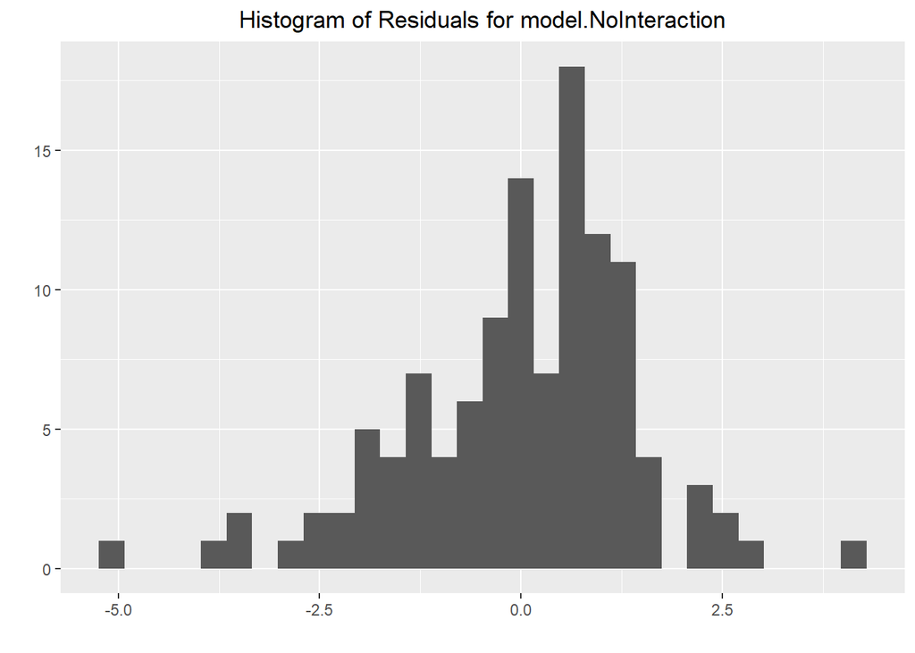

```r
# Response variable
#response_variable <- "CI_team"
#plot_dependent_variable_name <- "CI"

# Data to fit
data_modified_team <- team_data %>%
  select(TeamScore,
         params$dependent_response_team,
         Target,
         SessionOrder,
         Team)

# Plot location
setwd(figure_directory)

# Generate models with variable response
data_focus_team <- data_modified_team
model.NoInteraction <- model_data_Target_Session(df = data_focus_team, dependent =  params$dependent_response_team, model.type =  "NoInteraction", is.team = TRUE, is.robust = FALSE)

# Histogram of Residuals - model.NoInteraction
ggplot(model.NoInteraction, aes(x = .resid)) +
  geom_histogram(bins = 30) +
  labs(title = paste("Histogram of Residuals for model.NoInteraction"), x = "", y = "") +
  theme(plot.title = element_text(hjust = 0.5)) +
  ggsave(filename = paste("Histogram_Residuals_", params$dependent_response_name_NoSpace, "_NoInteraction_Team.png", sep = ""))
```

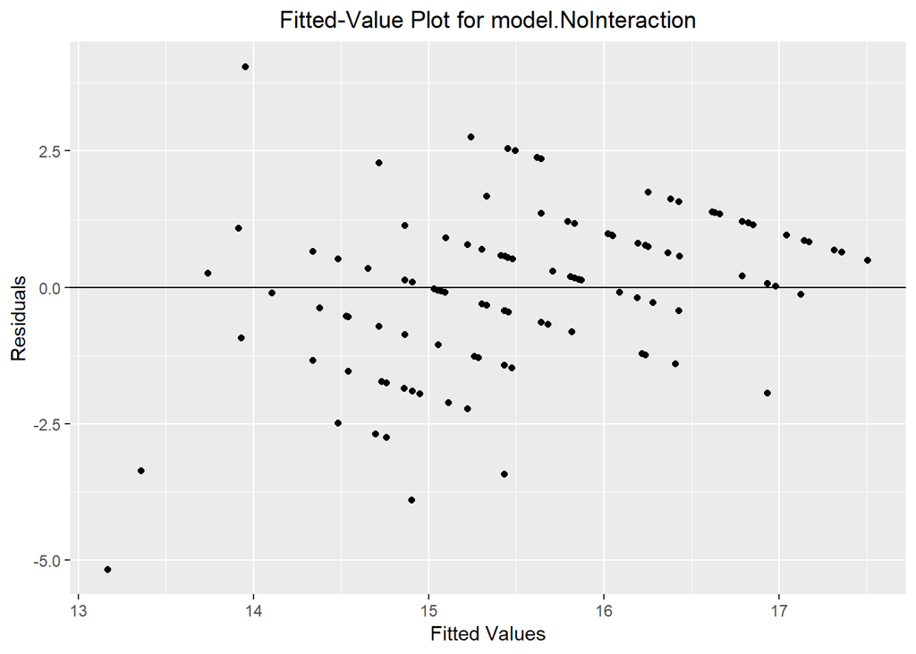

```r
# Fitted values - model.NoInteraction
ggplot(model.NoInteraction, aes(x = .fitted, y = .resid)) +
  geom_point() +
  geom_hline(yintercept = 0)+
  labs(title = paste("Fitted-Value Plot for model.NoInteraction"), x = "Fitted Values", y = "Residuals") +
  theme(plot.title = element_text(hjust = 0.5)) +
  ggsave(filename = paste("FitteValue_Residuals_", params$dependent_response_name_NoSpace, "_NoInteraction_Team.png", sep = ""))
```

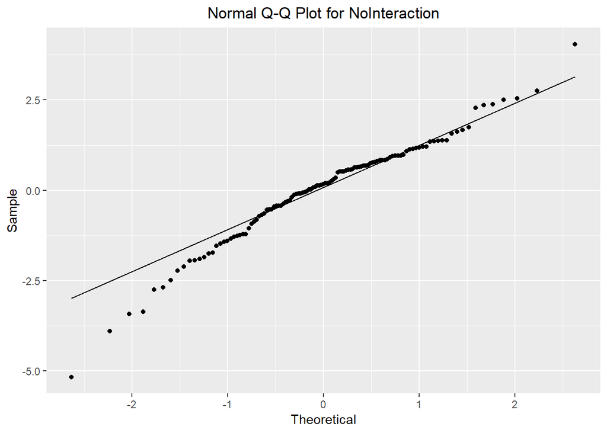

```r
# QQ plots - model.NoInteraction
ggplot(model.NoInteraction, aes(sample = .resid)) +
  stat_qq() +
  stat_qq_line()+
  labs(title = "Normal Q-Q Plot for NoInteraction", x = "Theoretical", y = "Sample") +
   theme(plot.title = element_text(hjust = 0.5)) +
  ggsave(filename = paste("QQ_Residuals_", params$dependent_response_name_NoSpace, "_NoInteraction_Team.png", sep = ""))
```

**model.NoInteraction**: Visually, it looks like assumptions 2 and 3 are violated in the fitted-value plot and the QQ plot, respectively. I will need to compare this model to a robust model to examine the influence of the apparent violation. If there is a noticeable difference, I will need to transform the data.

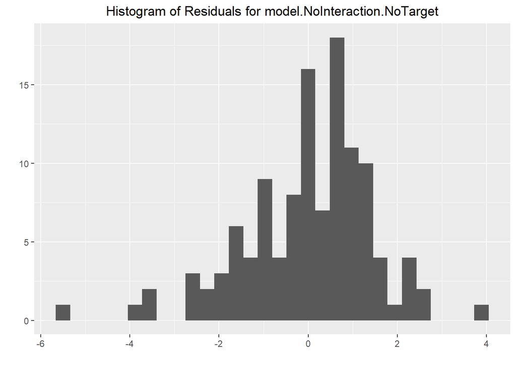

```r
# Response variable
#response_variable <- "CI_team"

# Data to fit
data_modified_team <- team_data %>%
  select(TeamScore,
         params$dependent_response_team,
         Target,
         SessionOrder,
         Team)

# Plot location
setwd(figure_directory)

# Generate models with variable response

data_focus_team <- data_modified_team
model.NoInteraction.NoTarget <- model_data_Target_Session(df = data_focus_team, dependent =  params$dependent_response_team, model.type =  "NoInteraction_NoTarget", is.team = TRUE, is.robust = FALSE)

# Histogram of Residuals - model.NoInteraction.NoTarget
ggplot(model.NoInteraction.NoTarget, aes(x = .resid)) +
  geom_histogram(bins = 30) +
  labs(title = paste("Histogram of Residuals for model.NoInteraction.NoTarget"), x = "", y = "") +
  theme(plot.title = element_text(hjust = 0.5)) +
  ggsave(filename = paste("Histogram_Residuals_", params$dependent_response_name_NoSpace, "_NoInteraction.NoTarget_Team.png", sep = ""))
```

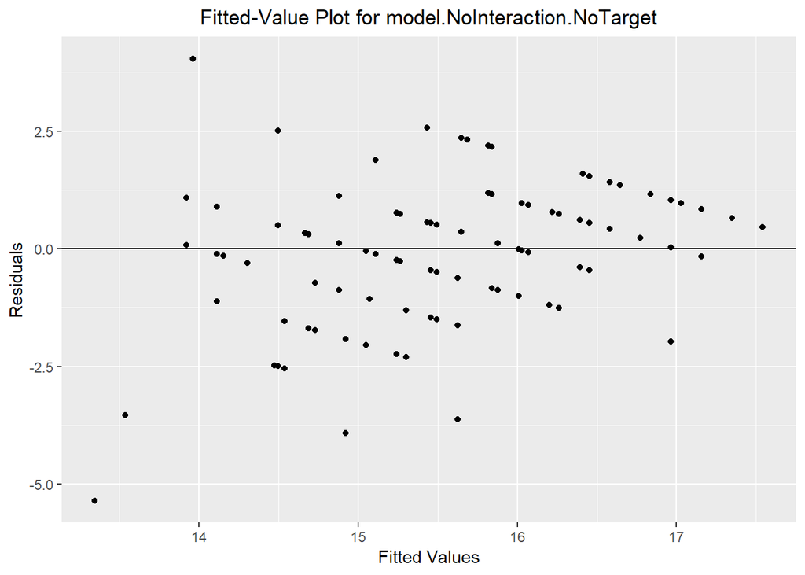

```r
# Fitted values - model.NoInteraction.NoTarget
ggplot(model.NoInteraction.NoTarget, aes(x = .fitted, y = .resid)) +
  geom_point() +
  geom_hline(yintercept = 0)+
  labs(title = paste("Fitted-Value Plot for model.NoInteraction.NoTarget"), x = "Fitted Values", y = "Residuals") +
  theme(plot.title = element_text(hjust = 0.5)) +
  ggsave(filename = paste("FitteValue_Residuals_", params$dependent_response_name_NoSpace, "_NoInteraction.NoTarget_Team.png", sep = ""))
```

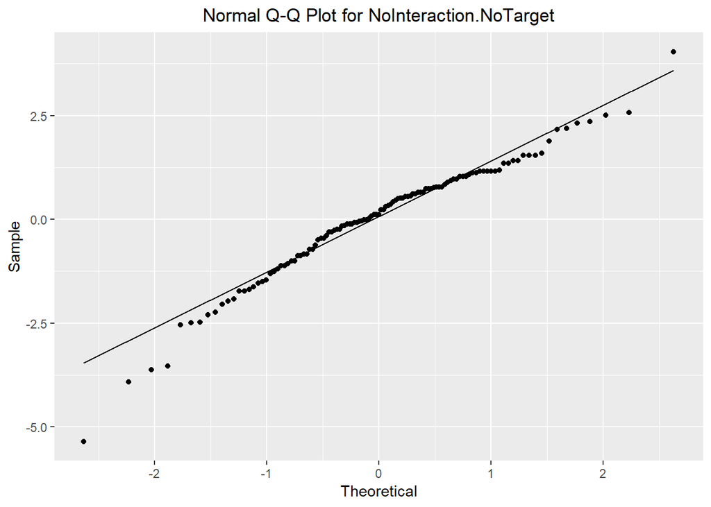

```r
# QQ plots - model.NoInteraction.NoTarget
ggplot(model.NoInteraction.NoTarget, aes(sample = .resid)) +
  stat_qq() +
  stat_qq_line()+
  labs(title = "Normal Q-Q Plot for NoInteraction.NoTarget", x = "Theoretical", y = "Sample") +
   theme(plot.title = element_text(hjust = 0.5)) +
  ggsave(filename = paste("QQ_Residuals_", params$dependent_response_name_NoSpace, "_NoInteraction.NoTarget_Team.png", sep = ""))
```

**model.NoInteraction.NoTarget**: Visually, it looks like assumptions 2 and 3 are violated in the fitted-value plot and the QQ plot, respectively. I will need to compare this model to a robust model to examine the influence of the apparent violation. If there is a noticeable difference, I will need to transform the data.

**Reflection:** It looks both models violated assumptions 2 and 3. I need to examine how this visual violation influences the model.

##### Q: Does the violation influence the linear model estimation?

I will use the robust estimation for linear mixed models found in the robustlmm package by Koller (2016). I will then compare the robust model to the non-robust model. If the estimated values are noticeably different, then the data will need to be transformed.

###### Model.NoInteraction

```r
# Response Variable
#response_variable <- "CI_team"

# Data to fit
data_modified_team <- team_data %>%
  select(TeamScore,
         params$dependent_response_team,
         Target,
         SessionOrder,
         Team)

data_focus_team <- data_modified_team

# Generate robust and non-robust models - NoInteraction
model.NoInteraction <- model_data_Target_Session(df = data_focus_team, dependent =  params$dependent_response_team, model.type =  "NoInteraction", is.team = TRUE, is.robust = FALSE)
rmodel.NoInteraction <- model_data_Target_Session(df = data_focus_team, dependent =  params$dependent_response_team, model.type =  "NoInteraction", is.team = TRUE, is.robust = TRUE)

comparision_results <- compare(model.NoInteraction, rmodel.NoInteraction, show.rho.functions = FALSE)

comparision_results %>%
  kable(caption = "model.NoInteraction") %>%
  kable_styling()
```

model.NoInteraction

|  | model.NoInteraction | rmodel.NoInteraction |
| --- | --- | --- |
| Coef |  |  |
| (Intercept) | 14.862 (0.375) | 15.0417 (0.368) |
| TargetInd_Team | 0.173 (0.370) | 0.0885 (0.330) |
| TargetTeam | 0.407 (0.370) | 0.3320 (0.330) |
| SessionOrder3 | 0.611 (0.370) | 0.4846 (0.330) |
| SessionOrder4 | 1.119 (0.370) | 1.0403 (0.330) |
| VarComp |  |  |
| (Intercept) \| Team | 1.09 | 1.32 |
| sigma | 1.63 | 1.42 |
| REML | 477 |  |

I do not see a concerning difference between the robust and non-robust **model.NoInteraction**. This suggests that I do not need to transform the data.

###### Model.NoInteraction.NoTarget

```r
# Response Variable
#response_variable <- "CI_team"

# Data to fit
data_modified_team <- team_data %>%
  select(TeamScore,
         params$dependent_response_team,
         Target,
         SessionOrder,
         Team)

data_focus_team <- data_modified_team

# Generate robust and non-robust models - NoInteraction.NoTarget
model.NoInteraction.NoTarget <- model_data_Target_Session(df = data_focus_team, dependent =  params$dependent_response_team, model.type =  "NoInteraction_NoTarget", is.team = TRUE, is.robust = FALSE)
rmodel.NoInteraction.NoTarget <- model_data_Target_Session(df = data_focus_team, dependent =  params$dependent_response_team, model.type =  "NoInteraction_NoTarget", is.team = TRUE, is.robust = TRUE)

comparision_results <- compare(model.NoInteraction.NoTarget, rmodel.NoInteraction.NoTarget, show.rho.functions = FALSE)

comparision_results %>%
  kable(caption = "model.NoInteraction.NoTarget") %>%
  kable_styling()
```

model.NoInteraction.NoTarget

|  | model.NoInteraction.NoTarget | rmodel.NoInteraction.NoTarget |
| --- | --- | --- |
| Coef |  |  |
| (Intercept) | 15.051 (0.313) | 15.193 (0.319) |
| SessionOrder3 | 0.615 (0.368) | 0.479 (0.330) |
| SessionOrder4 | 1.128 (0.368) | 1.046 (0.330) |
| VarComp |  |  |
| (Intercept) \| Team | 1.09 | 1.32 |
| sigma | 1.62 | 1.42 |
| REML | 478 |  |

I do not see a concerning difference between the robust and non-robust **model.NoInteraction.NoTarget**. This suggests that I do not need to transform the data.

##### Q: Are there any effects that are significant?

I want to determine if Target has a significant effect. I will examine the model itself, and then I will calculate the estimated marginal means to compare all three levels.

###### Model.NoInteraction

```r
# Response Variable
#response_variable <- "CI_team"

# Data to fit
data_modified_team <- team_data %>%
  select(TeamScore,
         params$dependent_response_team,
         Target,
         SessionOrder,
         Team)

data_focus_team <- data_modified_team

# Generate robust and non-robust models - NoInteraction
model.NoInteraction <- model_data_Target_Session(df = data_focus_team, dependent =  params$dependent_response_team, model.type =  "NoInteraction", is.team = TRUE, is.robust = FALSE)

summary(model.NoInteraction)
```

```
## Linear mixed model fit by REML. t-tests use Satterthwaite's method [
## lmerModLmerTest]
## Formula:
## as.formula(paste(dependent, "~ Target + SessionOrder + (1|Team)"))
##    Data: df
##
## REML criterion at convergence: 477
##
## Scaled residuals:
##     Min      1Q  Median      3Q     Max
## -3.1669 -0.4379  0.1024  0.5254  2.4786
##
## Random effects:
##  Groups   Name        Variance Std.Dev.
##  Team     (Intercept) 1.181    1.087
##  Residual             2.665    1.632
## Number of obs: 117, groups:  Team, 39
##
## Fixed effects:
##                Estimate Std. Error       df t value Pr(>|t|)
## (Intercept)     14.8622     0.3753 111.3039  39.605  < 2e-16 ***
## TargetInd_Team   0.1734     0.3702  74.0000   0.468  0.64090
## TargetTeam       0.4072     0.3698  74.0000   1.101  0.27439
## SessionOrder3    0.6109     0.3698  74.0000   1.652  0.10274
## SessionOrder4    1.1193     0.3702  74.0000   3.024  0.00343 **
## ---
## Signif. codes:  0 '***' 0.001 '**' 0.01 '*' 0.05 '.' 0.1 ' ' 1
##
## Correlation of Fixed Effects:
##             (Intr) TrgI_T TrgtTm SssnO3
## TargtInd_Tm -0.468
## TargetTeam  -0.480  0.500
## SessinOrdr3 -0.480 -0.026 -0.013
## SessinOrdr4 -0.468 -0.051 -0.026  0.500
```

The two variables are Target and Session Order. The reference variable is session 2 (not session 1). The data suggest that the Team and Ind_Team level do not have a significant effect in reference to the Ind level. It is also interesting to note that session 3 does not have a significant effect in reference to session 2. However, session 4 does have a significant effect in reference to session 2.

```r
# Response Variable
#response_variable <- "CI_team"

# Data to fit
data_modified_team <- team_data %>%
  select(TeamScore,
         params$dependent_response_team,
         Target,
         SessionOrder,
         Team)

data_focus_team <- data_modified_team

# Generate robust and non-robust models - NoInteraction
model.NoInteraction <- model_data_Target_Session(df = data_focus_team, dependent =  params$dependent_response_team, model.type =  "NoInteraction", is.team = TRUE, is.robust = FALSE)

emmeans(model.NoInteraction, list(pairwise ~ Target), adjust = "tukey")
```

```
## $`emmeans of Target`
##  Target   emmean    SE   df lower.CL upper.CL
##  Ind        15.4 0.314 95.3     14.8     16.1
##  Ind_Team   15.6 0.314 95.3     15.0     16.2
##  Team       15.8 0.314 95.2     15.2     16.5
##
## Results are averaged over the levels of: SessionOrder
## Degrees-of-freedom method: satterthwaite
## Confidence level used: 0.95
##
## $`pairwise differences of Target`
##  contrast        estimate   SE df t.ratio p.value
##  Ind - Ind_Team    -0.173 0.37 74 -0.468  0.8863
##  Ind - Team        -0.407 0.37 74 -1.101  0.5164
##  Ind_Team - Team   -0.234 0.37 74 -0.632  0.8028
##
## Results are averaged over the levels of: SessionOrder
## P value adjustment: tukey method for comparing a family of 3 estimates
```

The estimated marginal means shows no significant difference between any of the conditions (I.e., Ind, Team, Ind_Team).

```r
# Response Variable
#response_variable <- "CI_team"

# Data to fit
data_modified_team <- team_data %>%
  select(TeamScore,
         params$dependent_response_team,
         Target,
         SessionOrder,
         Team)

data_focus_team <- data_modified_team

# Generate robust and non-robust models - NoInteraction
model.NoInteraction <- model_data_Target_Session(df = data_focus_team, dependent =  params$dependent_response_team, model.type =  "NoInteraction", is.team = TRUE, is.robust = FALSE)

emmeans(model.NoInteraction, list(pairwise ~ SessionOrder), adjust = "tukey")
```

```
## $`emmeans of SessionOrder`
##  SessionOrder emmean    SE   df lower.CL upper.CL
##  2              15.1 0.314 95.3     14.4     15.7
##  3              15.7 0.314 95.2     15.0     16.3
##  4              16.2 0.314 95.3     15.6     16.8
##
## Results are averaged over the levels of: Target
## Degrees-of-freedom method: satterthwaite
## Confidence level used: 0.95
##
## $`pairwise differences of SessionOrder`
##  contrast estimate   SE df t.ratio p.value
##  2 - 3      -0.611 0.37 74 -1.652  0.2306
##  2 - 4      -1.119 0.37 74 -3.024  0.0095
##  3 - 4      -0.508 0.37 74 -1.375  0.3593
##
## Results are averaged over the levels of: Target
## P value adjustment: tukey method for comparing a family of 3 estimates
```

The results show only a significant difference between session 2 and session 4.

**Reflection:** There are no significant effects from the Target variables. There is also, only a significant difference between sessions 2 and 4. This suggests that there is little difference between session 2 and 3. This suggestion would that teams did not increase the number of correct team items collected when going from session 2 to 3. However, the teams did get significantly better when comparing session 2 to session 4. This would mean that teams got better overall.

###### Model.NoInteraction.NoTarget

```r
# Response Variable
#response_variable <- "CI_team"

# Data to fit
data_modified_team <- team_data %>%
  select(TeamScore,
         params$dependent_response_team,
         Target,
         SessionOrder,
         Team)

data_focus_team <- data_modified_team

# Generate robust and non-robust models - NoInteraction_NoTarget
model.NoInteraction.NoTarget <- model_data_Target_Session(df = data_focus_team, dependent =  params$dependent_response_team, model.type =  "NoInteraction_NoTarget", is.team = TRUE, is.robust = FALSE)

summary(model.NoInteraction.NoTarget)
```

```
## Linear mixed model fit by REML. t-tests use Satterthwaite's method [
## lmerModLmerTest]
## Formula: as.formula(paste(dependent, "~ SessionOrder + (1|Team)"))
##    Data: df
##
## REML criterion at convergence: 477.6
##
## Scaled residuals:
##     Min      1Q  Median      3Q     Max
## -3.2917 -0.5158  0.0751  0.5976  2.4870
##
## Random effects:
##  Groups   Name        Variance Std.Dev.
##  Team     (Intercept) 1.190    1.091
##  Residual             2.637    1.624
## Number of obs: 117, groups:  Team, 39
##
## Fixed effects:
##               Estimate Std. Error      df t value Pr(>|t|)
## (Intercept)    15.0513     0.3133 95.5336  48.047  < 2e-16 ***
## SessionOrder3   0.6154     0.3678 76.0000   1.673  0.09838 .
## SessionOrder4   1.1282     0.3678 76.0000   3.068  0.00299 **
## ---
## Signif. codes:  0 '***' 0.001 '**' 0.01 '*' 0.05 '.' 0.1 ' ' 1
##
## Correlation of Fixed Effects:
##             (Intr) SssnO3
## SessinOrdr3 -0.587
## SessinOrdr4 -0.587  0.500
```

The results suggest that the effect of session 3 was not significantly different from session 2, though it is approaching significance. The results also indicate that the effect of session 4 is significantly different from session 2.

```r
# Response Variable
#response_variable <- "CI_team"

# Data to fit
data_modified_team <- team_data %>%
  select(TeamScore,
         params$dependent_response_team,
         Target,
         SessionOrder,
         Team)

data_focus_team <- data_modified_team

# Generate robust and non-robust models - NoInteraction_NoTarget
model.NoInteraction.NoTarget <- model_data_Target_Session(df = data_focus_team, dependent =  params$dependent_response_team, model.type =  "NoInteraction_NoTarget", is.team = TRUE, is.robust = FALSE)

emmeans(model.NoInteraction.NoTarget, list(pairwise ~ SessionOrder), adjust = "tukey")
```

```
## $`emmeans of SessionOrder`
##  SessionOrder emmean    SE   df lower.CL upper.CL
##  2              15.1 0.313 95.5     14.4     15.7
##  3              15.7 0.313 95.5     15.0     16.3
##  4              16.2 0.313 95.5     15.6     16.8
##
## Degrees-of-freedom method: satterthwaite
## Confidence level used: 0.95
##
## $`pairwise differences of SessionOrder`
##  contrast estimate    SE df t.ratio p.value
##  2 - 3      -0.615 0.368 76 -1.673  0.2221
##  2 - 4      -1.128 0.368 76 -3.068  0.0083
##  3 - 4      -0.513 0.368 76 -1.394  0.3489
##
## P value adjustment: tukey method for comparing a family of 3 estimates
```

The results indicate there is a significant difference between session 2 and 4.

**Reflection:** Overall, the only major finding is that there is only a significant difference between session 2 and session 4.

#### Individual

We learned that **model.NoInteraction** best describe the individual level data(see previous analysis).

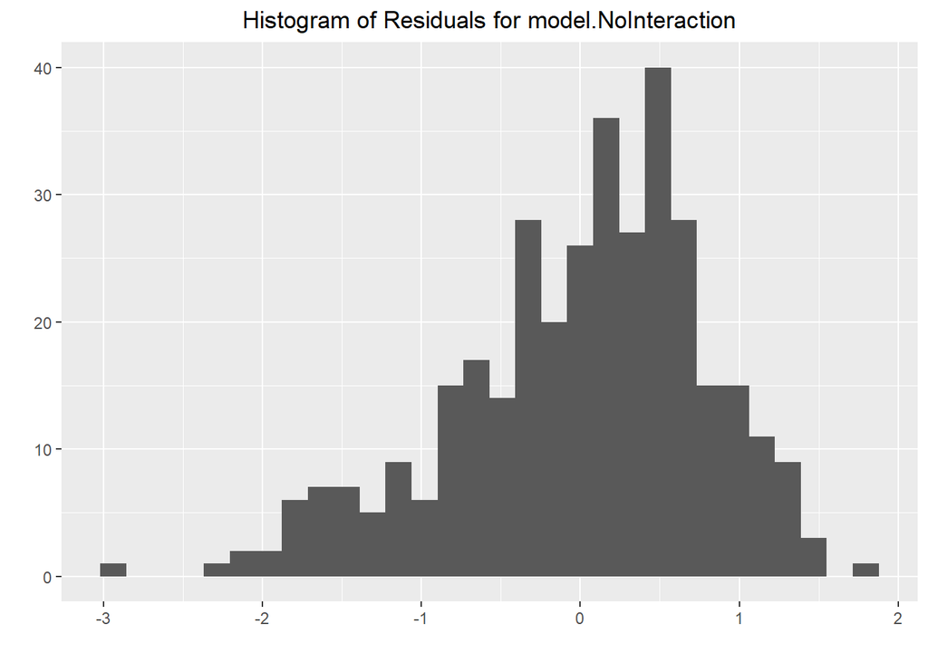

```r
# Response variable
#response_variable <- "CI_ind"
#plot_dependent_variable_name <- "CI"

# Data to model
data_modified_ind <- ind_data %>%
  select(params$dependent_response_ind,
         Target,
         SessionOrder,
         Team,
         Player_ID)

# Plot location
setwd(figure_directory)

# Generate models with variable response

data_focus_ind <- data_modified_ind
model.NoInteraction <- model_data_Target_Session(df = data_focus_ind, dependent =  params$dependent_response_ind, model.type =  "NoInteraction", is.team = FALSE, is.robust = FALSE)

# Histogram of Residuals - model.NoInteraction
ggplot(model.NoInteraction, aes(x = .resid)) +
  geom_histogram(bins = 30) +
  labs(title = paste("Histogram of Residuals for model.NoInteraction"), x = "", y = "") +
  theme(plot.title = element_text(hjust = 0.5)) +
  ggsave(paste("Histogram_Residuals_", params$dependent_response_name_NoSpace, "_NoInteraction_Ind.png", sep =""))
```

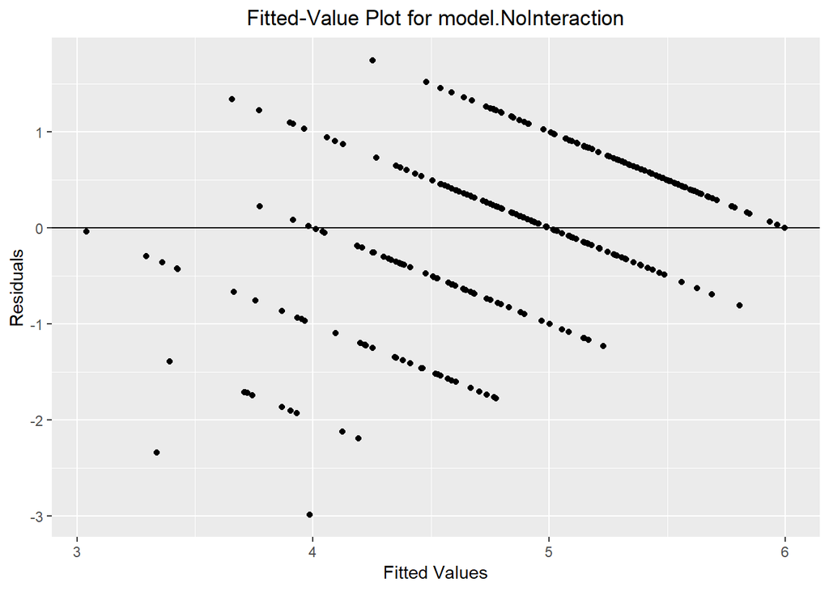

```r
# Fitted values - model.NoInteraction
ggplot(model.NoInteraction, aes(x = .fitted, y = .resid)) +
  geom_point() +
  geom_hline(yintercept = 0)+
  labs(title = paste("Fitted-Value Plot for model.NoInteraction"), x = "Fitted Values", y = "Residuals") +
  theme(plot.title = element_text(hjust = 0.5)) +
  ggsave(paste("FittedValue_Residuals_", params$dependent_response_name_NoSpace, "_NoInteraction_Ind.png", sep =""))
```

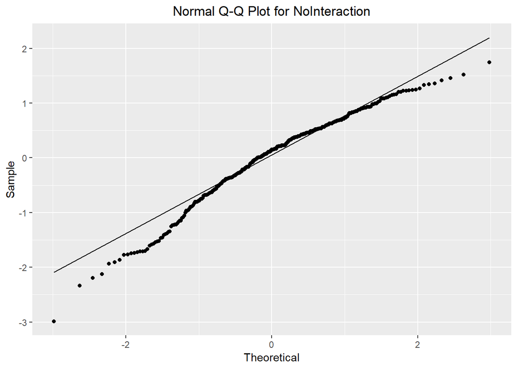

```r
# QQ plots - model.NoInteraction
ggplot(model.NoInteraction, aes(sample = .resid)) +
  stat_qq() +
  stat_qq_line()+
  labs(title = "Normal Q-Q Plot for NoInteraction", x = "Theoretical", y = "Sample") +
   theme(plot.title = element_text(hjust = 0.5)) +
  ggsave(paste("QQ_Residuals_", params$dependent_response_name_NoSpace, "_NoInteraction_Ind.png", sep =""))
```

**model.NoInteraction:** Visually, it looks like the model violates assumption 2 and 3 in the fitted-value plot and the QQ plot, respectively. I will need to compare this model to a robust model to examine the influence of the apparent violation. If there is a noticeable difference, I will need to transform the data.

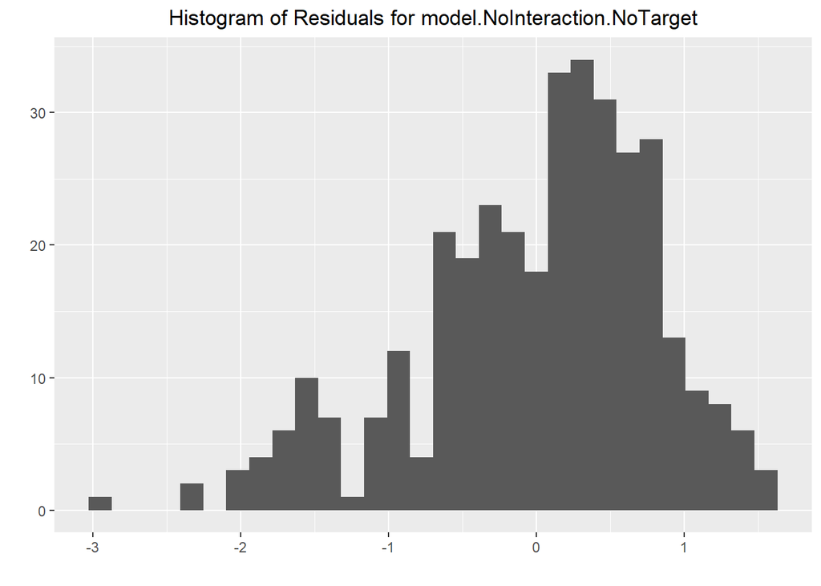

```r
# Response variable
#response_variable <- "CI_ind"
#plot_dependent_variable_name <- "CI"

# Data to model
data_modified_ind <- ind_data %>%
  select(params$dependent_response_ind,
         Target,
         SessionOrder,
         Team,
         Player_ID)

# Plot location
setwd(figure_directory)

# Generate models with variable response

data_focus_ind <- data_modified_ind
model.NoInteraction.NoTarget <- model_data_Target_Session(df = data_focus_ind, dependent =  params$dependent_response_ind, model.type =  "NoInteraction_NoTarget", is.team = FALSE, is.robust = FALSE)

# Histogram of Residuals - model.NoInteraction.NoTarget
ggplot(model.NoInteraction.NoTarget, aes(x = .resid)) +
  geom_histogram(bins = 30) +
  labs(title = paste("Histogram of Residuals for model.NoInteraction.NoTarget"), x = "", y = "") +
  theme(plot.title = element_text(hjust = 0.5)) +
  ggsave(paste("Histogram_Residuals_", params$dependent_response_name_NoSpace, "_NoInteraction.NoTarget_Ind.png", sep =""))
```

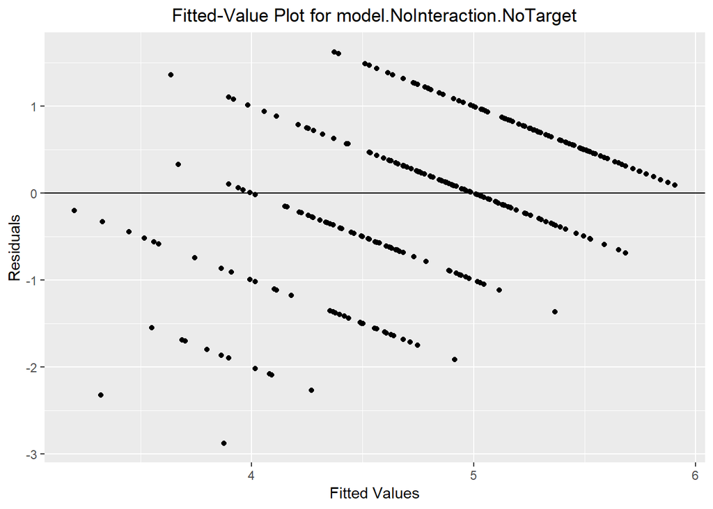

```r
# Fitted values - model.NoInteraction.NoTarget
ggplot(model.NoInteraction.NoTarget, aes(x = .fitted, y = .resid)) +
  geom_point() +
  geom_hline(yintercept = 0)+
  labs(title = paste("Fitted-Value Plot for model.NoInteraction.NoTarget"), x = "Fitted Values", y = "Residuals") +
  theme(plot.title = element_text(hjust = 0.5)) +
  ggsave(paste("FittedValue_Residuals_", params$dependent_response_name_NoSpace, "_NoInteraction.NoTarget_Ind.png", sep =""))
```

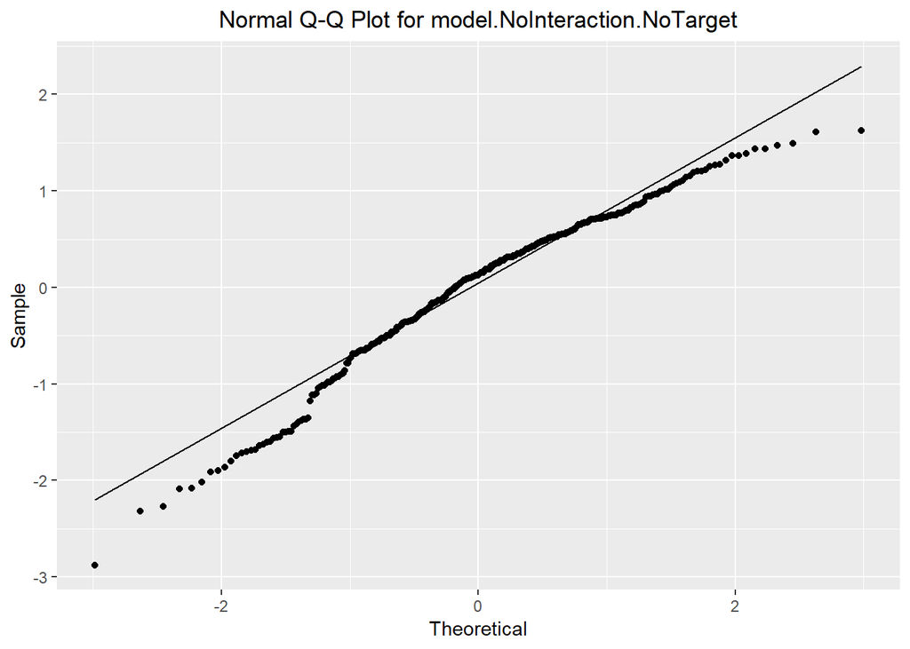

```r
# QQ plots - model.NoInteraction.NoTarget
ggplot(model.NoInteraction.NoTarget, aes(sample = .resid)) +
  stat_qq() +
  stat_qq_line()+
  labs(title = "Normal Q-Q Plot for model.NoInteraction.NoTarget", x = "Theoretical", y = "Sample") +
   theme(plot.title = element_text(hjust = 0.5)) +
  ggsave(paste("QQ_Residuals_", params$dependent_response_name_NoSpace, "_NoInteraction.NoTarget_Ind.png", sep =""))
```

**model.NoInteraction.NoTarget:** Visually, it looks likes assumptions 2 and 3 are violated. I will need to compare the classical model to the robust model to see how these violations will influence the model.

**Reflection:** Overal, it looks like assumption 2 and 3 are violated, and I need to see if these violations influence the model.

##### Q: Does the violation influence the model estimation?

I will use the robust estimation for linear mixed models found in the robustlmm package by Koller (2016). I will then compare the robust model to the non-robust model. If the estimated values are noticeably different, then data will need to be transformed.

###### Model.NoInteraction

```r
#response_variable <- "CI_ind"

# Data to model
data_modified_ind <- ind_data %>%
  select(params$dependent_response_ind,
         Target,
         SessionOrder,
         Team,
         Player_ID)

# Generate models with variable response
data_focus_ind <- data_modified_ind
model.NoInteraction <- model_data_Target_Session(df = data_focus_ind, dependent =  params$dependent_response_ind, model.type =  "NoInteraction", is.team = FALSE, is.robust = FALSE)
rmodel.NoInteraction <- model_data_Target_Session(df = data_focus_ind, dependent =  params$dependent_response_ind, model.type =  "NoInteraction", is.team = FALSE, is.robust = TRUE)

comparision_results <- compare(model.NoInteraction, rmodel.NoInteraction, show.rho.functions = FALSE)

comparision_results %>%
  kable(caption = "model.NoInteraction") %>%
  kable_styling()
```

model.NoInteraction

|  | model.NoInteraction | rmodel.NoInteraction |
| --- | --- | --- |
| Coef |  |  |
| (Intercept) | 4.7685 (0.136) | 4.844 (0.146) |
| TargetInd_Team | -0.1727 (0.117) | -0.179 (0.128) |
| TargetTeam | 0.0846 (0.117) | 0.090 (0.128) |
| SessionOrder3 | 0.1241 (0.117) | 0.137 (0.128) |
| SessionOrder4 | 0.3678 (0.117) | 0.363 (0.128) |
| VarComp |  |  |
| (Intercept) \| Player_ID | 0.495 | 0.000 |
| (Intercept) \| Team | 0.457 | 0.547 |
| sigma | 0.893 | 0.957 |
| REML | 1033 |  |

**model.NoInteraction:** I do not see a noticeable difference between the two models.

###### model.NoInteraction.NoTarget

```r
#response_variable <- "CI_ind"

# Data to model
data_modified_ind <- ind_data %>%
  select(params$dependent_response_ind,
         Target,
         SessionOrder,
         Team,
         Player_ID)

# Generate models with variable response
data_focus_ind <- data_modified_ind
model.NoInteraction.NoTarget <- model_data_Target_Session(df = data_focus_ind, dependent =  params$dependent_response_ind, model.type =  "NoInteraction_NoTarget", is.team = FALSE, is.robust = FALSE)
rmodel.NoInteraction.NoTarget <- model_data_Target_Session(df = data_focus_ind, dependent =  params$dependent_response_ind, model.type =  "NoInteraction_NoTarget", is.team = FALSE, is.robust = TRUE)

comparision_results <- compare(model.NoInteraction.NoTarget, rmodel.NoInteraction.NoTarget, show.rho.functions = FALSE)

comparision_results %>%
  kable(caption = "model.NoInteraction.NoTarget") %>%
  kable_styling()
```

model.NoInteraction.NoTarget

|  | model.NoInteraction.NoTarget | rmodel.NoInteraction.NoTarget |
| --- | --- | --- |
| Coef |  |  |
| (Intercept) | 4.744 (0.120) | 4.821 (0.127) |
| SessionOrder3 | 0.120 (0.118) | 0.140 (0.128) |
| SessionOrder4 | 0.359 (0.118) | 0.346 (0.128) |
| VarComp |  |  |
| (Intercept) \| Player_ID | 0.491 | 0.000 |
| (Intercept) \| Team | 0.457 | 0.548 |
| sigma | 0.899 | 0.952 |
| REML | 1032 |  |

**model.NoInteraction.NoTarget:** I see no noticeable difference between the two models.

##### Q: Are there any effects that are significant?

###### model.NoInteraction

```r
#Response variable
#response_variable <- "CI_ind"

# Data to model
data_modified_ind <- ind_data %>%
  select(params$dependent_response_ind,
         Target,
         SessionOrder,
         Team,
         Player_ID)

data_focus_ind <- data_modified_ind

# Generate models with variable response
model.NoInteraction <- model_data_Target_Session(df = data_focus_ind, dependent =  params$dependent_response_ind, model.type =  "NoInteraction", is.team = FALSE, is.robust = FALSE)

summary(model.NoInteraction)
```

```
## Linear mixed model fit by REML. t-tests use Satterthwaite's method [
## lmerModLmerTest]
## Formula:
## as.formula(paste(dependent, "~ Target + SessionOrder + (1|Team) + (1| Player_ID)"))
##    Data: df
##
## REML criterion at convergence: 1032.7
##
## Scaled residuals:
##     Min      1Q  Median      3Q     Max
## -3.3424 -0.4838  0.1685  0.6019  1.9573
##
## Random effects:
##  Groups    Name        Variance Std.Dev.
##  Player_ID (Intercept) 0.2450   0.4950
##  Team      (Intercept) 0.2093   0.4575
##  Residual              0.7978   0.8932
## Number of obs: 351, groups:  Player_ID, 117; Team, 39
##
## Fixed effects:
##                 Estimate Std. Error        df t value Pr(>|t|)
## (Intercept)      4.76854    0.13599 120.98463  35.066  < 2e-16 ***
## TargetInd_Team  -0.17271    0.11693 229.99991  -1.477  0.14105
## TargetTeam       0.08459    0.11682 229.99991   0.724  0.46976
## SessionOrder3    0.12409    0.11682 229.99991   1.062  0.28925
## SessionOrder4    0.36783    0.11693 229.99991   3.146  0.00188 **
## ---
## Signif. codes:  0 '***' 0.001 '**' 0.01 '*' 0.05 '.' 0.1 ' ' 1
##
## Correlation of Fixed Effects:
##             (Intr) TrgI_T TrgtTm SssnO3
## TargtInd_Tm -0.408
## TargetTeam  -0.419  0.500
## SessinOrdr3 -0.419 -0.026 -0.013
## SessinOrdr4 -0.408 -0.051 -0.026  0.500
```

The results show that only the effects of Team and Ind_Team are not significantly different from the Ind level. The results show the effect of session 3 is not significantly different from session 2, but the results also show that the effect of session 4 is significantly different from session two.

```r
#Response variable
#response_variable <- "CI_ind"

# Data to model
data_modified_ind <- ind_data %>%
  select(params$dependent_response_ind,
         Target,
         SessionOrder,
         Team,
         Player_ID)

data_focus_ind <- data_modified_ind

# Generate models with variable response
model.NoInteraction <- model_data_Target_Session(df = data_focus_ind, dependent =  params$dependent_response_ind, model.type =  "NoInteraction", is.team = FALSE, is.robust = FALSE)

emmeans(model.NoInteraction, list(pairwise ~ Target), adjust = "tukey")
```

```
## $`emmeans of Target`
##  Target   emmean    SE   df lower.CL upper.CL
##  Ind        4.93 0.120 79.0     4.69     5.17
##  Ind_Team   4.76 0.120 79.0     4.52     5.00
##  Team       5.02 0.119 78.9     4.78     5.25
##
## Results are averaged over the levels of: SessionOrder
## Degrees-of-freedom method: satterthwaite
## Confidence level used: 0.95
##
## $`pairwise differences of Target`
##  contrast        estimate    SE  df t.ratio p.value
##  Ind - Ind_Team    0.1727 0.117 230  1.477  0.3039
##  Ind - Team       -0.0846 0.117 230 -0.724  0.7495
##  Ind_Team - Team  -0.2573 0.117 230 -2.203  0.0729
##
## Results are averaged over the levels of: SessionOrder
## P value adjustment: tukey method for comparing a family of 3 estimates
```

**Reflection:** The result showed that the difference between Ind_Team and Team condition is **approaching significance**. This result suggests that more data is needed to reach significance. If this result reaches significance, then it means that the individuals collected more correct individual items in the Team condition when compared to the Ind_Team condition.

```r
#Response variable
#response_variable <- "CI_ind"

# Data to model
data_modified_ind <- ind_data %>%
  select(params$dependent_response_ind,
         Target,
         SessionOrder,
         Team,
         Player_ID)

data_focus_ind <- data_modified_ind

# Generate models with variable response
model.NoInteraction <- model_data_Target_Session(df = data_focus_ind, dependent =  params$dependent_response_ind, model.type =  "NoInteraction", is.team = FALSE, is.robust = FALSE)

emmeans(model.NoInteraction, list(pairwise ~ SessionOrder), adjust = "tukey")
```

```
## $`emmeans of SessionOrder`
##  SessionOrder emmean    SE   df lower.CL upper.CL
##  2              4.74 0.120 79.0     4.50     4.98
##  3              4.86 0.119 78.9     4.63     5.10
##  4              5.11 0.120 79.0     4.87     5.34
##
## Results are averaged over the levels of: Target
## Degrees-of-freedom method: satterthwaite
## Confidence level used: 0.95
##
## $`pairwise differences of SessionOrder`
##  contrast estimate    SE  df t.ratio p.value
##  2 - 3      -0.124 0.117 230 -1.062  0.5385
##  2 - 4      -0.368 0.117 230 -3.146  0.0053
##  3 - 4      -0.244 0.117 230 -2.087  0.0949
##
## Results are averaged over the levels of: Target
## P value adjustment: tukey method for comparing a family of 3 estimates
```

**Reflection:** The results showed a significant difference between sessions 2 and 4. Meaning that participants in session 4 collected more correct individual items in session 4 when compared to session 2. The difference between session 3 and 4 is approaching significance, which indicates that more data is needed to reach significance. If this result is significant, then participants in session 4 collect more correct individual items than they do in session 3. This is what I would expect to find.

###### model.NoInteraction.NoTarget

```r
#Response variable
#response_variable <- "CI_ind"

# Data to model
data_modified_ind <- ind_data %>%
  select(params$dependent_response_ind,
         Target,
         SessionOrder,
         Team,
         Player_ID)

data_focus_ind <- data_modified_ind

# Generate models with variable response
model.NoInteraction.NoTarget <- model_data_Target_Session(df = data_focus_ind, dependent =  params$dependent_response_ind, model.type =  "NoInteraction_NoTarget", is.team = FALSE, is.robust = FALSE)

summary(model.NoInteraction.NoTarget)
```

```
## Linear mixed model fit by REML. t-tests use Satterthwaite's method [
## lmerModLmerTest]
## Formula:
## as.formula(paste(dependent, "~ SessionOrder + (1|Team) + (1| Player_ID)"))
##    Data: df
##
## REML criterion at convergence: 1032.5
##
## Scaled residuals:
##     Min      1Q  Median      3Q     Max
## -3.1988 -0.5138  0.1417  0.6161  1.8095
##
## Random effects:
##  Groups    Name        Variance Std.Dev.
##  Player_ID (Intercept) 0.2415   0.4914
##  Team      (Intercept) 0.2093   0.4575
##  Residual              0.8083   0.8990
## Number of obs: 351, groups:  Player_ID, 117; Team, 39
##
## Fixed effects:
##               Estimate Std. Error       df t value Pr(>|t|)
## (Intercept)     4.7436     0.1197  79.5510  39.615  < 2e-16 ***
## SessionOrder3   0.1197     0.1175 232.0004   1.018  0.30974
## SessionOrder4   0.3590     0.1175 232.0004   3.054  0.00252 **
## ---
## Signif. codes:  0 '***' 0.001 '**' 0.01 '*' 0.05 '.' 0.1 ' ' 1
##
## Correlation of Fixed Effects:
##             (Intr) SssnO3
## SessinOrdr3 -0.491
## SessinOrdr4 -0.491  0.500
```

The results show that session 4 has a significant effect when compared to session 2. The results also show that session 3 does not have a significant effect when compared to session 2.

```r
#Response variable
#response_variable <- "CI_ind"

# Data to model
data_modified_ind <- ind_data %>%
  select(params$dependent_response_ind,
         Target,
         SessionOrder,
         Team,
         Player_ID)

data_focus_ind <- data_modified_ind

# Generate models with variable response
model.NoInteraction.NoTarget <- model_data_Target_Session(df = data_focus_ind, dependent =  params$dependent_response_ind, model.type =  "NoInteraction_NoTarget", is.team = FALSE, is.robust = FALSE)

emmeans(model.NoInteraction.NoTarget, list(pairwise ~ SessionOrder), adjust = "tukey")
```

```
## $`emmeans of SessionOrder`
##  SessionOrder emmean   SE   df lower.CL upper.CL
##  2              4.74 0.12 79.5     4.51     4.98
##  3              4.86 0.12 79.5     4.62     5.10
##  4              5.10 0.12 79.5     4.86     5.34
##
## Degrees-of-freedom method: satterthwaite
## Confidence level used: 0.95
##
## $`pairwise differences of SessionOrder`
##  contrast estimate    SE  df t.ratio p.value
##  2 - 3      -0.120 0.118 232 -1.018  0.5663
##  2 - 4      -0.359 0.118 232 -3.054  0.0071
##  3 - 4      -0.239 0.118 232 -2.036  0.1060
##
## P value adjustment: tukey method for comparing a family of 3 estimates
```

**Reflection:** The results show a significant difference between session 2 and session 4. This means that participants collected more correct individual items in session 4 when compared to session 2.

#### Summary and reflection

Overall, there were no exciting significant findings produced by either of the models. However, I think that it is worth mentioning that at the individual level, the estimated marginal means based on model.NoInteraction showed that the difference between Ind_Team and Team is **approaching significance** (p = 0.0729). This suggests that more data is needed. If it eventually reaches significance, then the difference indicates that participants collected more correct individual items in the Team condition when compared to the Ind_Team condition. Furthermore, this would mean that Team feedback is needed to increase the number of correct individual items collected by participants.

# References

Field, A. P., & Wilcox, R. R. (2017). Robust statistical methods: A primer for clinical psychology and experimental psychopathology researchers. *Behaviour Research and Therapy*, *98*, 19–38. https://doi.org/10.1016/j.brat.2017.05.013

Galwey, N. W. (2014). Testing the assumptions of the analyses: Inspection of the residual values. In *Introduction to mixed modelling: Beyond regression and analysis of variance* (Second). Chichester, United Kingdom: John Wiley & Sons, Ltd.

Johnson, P. C. (2014). Extension of Nakagawa & Schielzeth’s R 2 GLMM to random slopes models. *Methods in Ecology and Evolution*, *5*(9), 944–946. https://doi.org/10.1111/2041-210X.12225

Koller, M. (2016). robustlmm : An R Package for Robust Estimation of Linear Mixed-Effects Models. *Journal of Statistical Software*, *75*(6). https://doi.org/10.18637/jss.v075.i06

Nakagawa, S., & Schielzeth, H. (2013). A general and simple method for obtaining R 2 from generalized linear mixed-effects models. *Methods in Ecology and Evolution*, *4*(2), 133–142. https://doi.org/10.1111/j.2041-210x.2012.00261.x

Tukey, J. W. (1977). *Exploratory data analysis*. Reading, Mass.: Addison-Wesley Pub.